# Methodology

Authors

Jolyon Miles-Wilson

Celestin Okoroji

Published

July 3, 2025

- Add css file to improve styling?

# 1 Participants and Design

To achieve a robust estimate of outsourced workers, the sample was weighted by age, gender, and education, region, and ethnicity. The ethnic minority sub-sample (1,435 respondents) was also weighted separately by age, gender, and region to ensure that findings related to ethnic minority adults were fully representative. Targets were estimated using data from the Labour Force Survey, the 2021 Census for England and Wales, and the Northern Ireland Census.

This sample had median age 42 (SD = 13.02). 51% of respondents identified as female, 48% as male, 0.14% as other, and 0.65% preferred not to identify a gender. 76% of respondents identified as ‘English / Welsh / Scottish / Northern Irish / British’ (see Section 7.3 for a detailed breakdown of ethnicity).

Soft quotas on age, gender, and region were implemented to ensure broad representativeness, and the final data was weighted to targets based on age, gender, education, region, and ethnicity. The targets were based on the weighted data from study 1. The survey population had a mean Age of 38.9 (SD = 13.0). 42.4% Female and 65.5% White British. A small proportion of respondents had previously participated in study 1 and met the outsourced criteria (5%).

Both surveys were administered online.

An initial pilot study aimed to refine the diagnostic questions used to identify outsourced workers, ensuring they aligned with JRF’s initial definition and could be accurately answered by survey respondents. The diagnostic questions and feedback follow-ups were run on Opinium’s political omnibus, a nationally and politically representative sample of 2,055 UK adults between 30 August and 1 September 2023. The questions were filtered to those in work, resulting in a total of 1,200 respondents. Data from this pilot study is not reported here.

# 2 Measures

## 2.1 Study 1- Nationally representative survey

- I believe some questions were replicated from national survey’s so lets explicate that
- Discuss the issue of pay calcs (e.g. basic overview and then refer to the section on it)
- Discuss the issue of defining outsourcing ((e.g. basic overview and then refer to the section on it))
- link to the data dictionary

### 2.1.1 Income calculations ([**perhaps more detailed than necessary in this section**])

Respondents could choose how they provided information about their income. Firstly, they could choose the payment period for which to express their income from the following options:

- Annually / per year
- Monthly
- Weekly
- Hourly

Secondly, they could choose either an ‘open’ form of reporting or a ‘closed’ form. The open form required respondents to type in their pay for the payment period they chose. The closed form required respondents to select which income bracket their pay belonged to from a list of options.

The annual options were:

- Less than £5,600 a year
- £5,600 up to £11,200
- £11,201 up to £16,800
- £16,801 up to £22,400
- £22,401 up to £28,000
- £28,001 up to £33,600
- £33,601 up to £39,200
- £39,201 up to £44,800
- £44,801 up to £50,400
- £50,401 up to £56,000
- Over £56,000 a year
- Prefer not to say

The monthly options were:

- Less than £470 a month
- £470 up to £940
- £941 up to £1,410
- £1,411 up to £1,880
- £1,881 up to £2,350
- £2,351 up to £2,820
- £2,821 up to £3,290
- £3,291 up to £3,760
- £3,761 up to £4,230
- £4,231 up to £4,700
- Over £4,700 a month
- Prefer not to say

The weekly options were:

- Less than £110 a week
- £110 up to £220
- £221 up to £330
- £331 up to £440
- £441 up to £550
- £551 up to £660
- £661 up to £770
- £771 up to £880
- £881 up to £990
- £991 up to £1,100
- Over £1,100 a week
- Prefer not to say

The hourly options were:

- Less than £8.91 an hour
- £8.91 up to £10.00
- £10.01 up to £12.00
- £12.01 up to £14.00
- £14.01 up to £16.00
- £16.01 up to £18.00
- £18.01 up to £20.00
- £20.01 up to £22.00
- £22.01 up to £24.00
- £24.01 up to £27.00
- £27.01 up to £30.00
- Over £30.00 an hour
- Prefer not to say

7499 respondents answered using the open method. 1445 respondents answered using the closed method. 1211 did not answer either.

We equivalised respondents’ income across the reporting options in two steps. Firstly, we converted closed income responses to continuous numeric values by taking the midpoint of the income brackets, or the value of the “less than” and “over” values. For example, a closed response of “£5,600 up to £11,200” would be converted to £8400; and a closed response of “Less than £5,600 a year” would be converted to £5600. These converted closed responses were combined with the open responses to produce a single continous income variable across payment periods.

Next, we expressed all respondents’ income in annual, weekly, and hourly periods. To do this we made an assumption about the number of working weeks in a year based on the minimum holiday entitlement of 28 days. We calculated the total number of weeks in a year as 365 / 7 = 52.14, the total number of non-working weeks as 28 / 5 = 5.6, and thus the total number of working weeks as 52.14 - 5.6 = 46.54.

With this figure and the number of hours worked per week, we could convert incomes provided in one payment period to another. The table below shows how this was achieved.

| Income provided... | Formula to convert to annual | Formula to convert to weekly | Formula to convert to hourly |
| --- | --- | --- | --- |
| ... annually | = income | = income / working weeks | = weekly income / hours worked per week |
| ... monthly | = income x 12 | = (income x 12) / working weeks | = weekly income / hours worked per week |
| ... weekly | = income x working weeks | = income | = weekly income / hours worked per week |
| ... hourly | = income x hours per week x working weeks | = income x hours per week | = weekly income / hours worked per week |

## 2.2 Study 2 - Outsourced workers survey

In the follow up survey of outsourced workers the data focuses on workers experiences and perceptions of outsourced work. The dataset is large containing 214 variables. Analysis of all the variables was beyond the scope of the report thus we focus on a subset of the data pertaining to outsourced workers experiences of rights violations, discrimination, job clarity, benefits and drawbacks of outsourced work and potential improvements to their work arrangements.

A data dictionary is available from the [Github Repository](https://github.com/JustKnowledge-UK/jrf_nat_rep) associated with this project along with all code used to produce the analyses.

# 3 Analysis - Study 1

- Determining if the worker is outsourced
- Calculating Low/Not Low pay
- Explain the analyses (e.g. any models that actually appear in the final output)

## 3.1 Defining outsourcing

Workers were defined as outsourced based on responses to a set of diagnostic questions. Three questions asked respondents directly about whether they considered themselves outsourced and/or agency workers.

The first of these questions asked respondents to indicate directly whether they considered themselves outsourced by selecting one of the following options:

1. I am sure I’m an outsourced worker
2. I think I might be an outsourced worker
3. I am not an outsourced worker

The second question asked respondents to indicate whether they considered themselves an agency worker by selecting from three options. For respondents who responded 1 or 2 to question 1, the options were:

1. I am sure that I’m also an agency worker
2. I think I might also be an agency worker
3. I am not an agency worker

For respondents who responded 3 to question 1, the options were:

1. I am sure that I’m an agency worker
2. I think I might be an agency worker
3. I am not an agency worker

Respondents were also asked whether the work they do was long- or short-term by selecting one of:

1. I’m hired to do work which an organisation needs doing on a long-term or ongoing basis.
2. I’m hired to do work which an organisation needs doing on a short-term or temporary basis.
3. Other (please specify)

Workers were categorised into three mutually exclusive sub groups based on their responses to the above questions.

1. A respondent was categorised as ‘**clearly outsourced**’ if they responded ‘I am sure I’m an outsourced worker’ or ‘I think I might be an outsourced worker’ **and** ‘I’m hired to do work which an organisation needs doing on a long-term or ongoing basis.’.
2. A respondent was categorised as ‘**likely agency**’ if they responded ‘I am sure that I’m an agency worker’ **and** ‘I’m hired to do work which an organisation needs doing on a long-term or ongoing basis’, **excluding** those people who are already defined as being ‘clearly outsourced’.
3. A respondent was categorised as belonging to the ‘**high indicators**’ group if they responded TRUE to five or six [CAN THIS BE EXPRESSED AS $\ge$ 5?] of the outsourcing indicators, as well as responding ‘I’m hired to do work which an organisation needs doing on a long-term or ongoing basis’, **excluding** those people who were already defined as ‘clearly outsourced’ or ‘likely agency’.

Together, these three sub groups form the classification of ‘outsourced workers’ considered in this report. Throughout the report, the term ‘outsourced’ refers to workers across the three sub groups. In places, analysis considers the three sub groups separately, in which case the groups will be referred to by name as ‘clearly outsourced’, ‘likely agency’, or ‘high indicators’.

## 3.2 Defining low pay

A ‘low pay’ binary variable was created by implementing an income threshold below which respondents were considered to be on a relatively low income. In line with with the [Organisation for Economic Co-operation and Development](https://www.oecd.org/en/data/indicators/incidence-of-low-and-high-pay.html), we set the threshold at two-thirds median weekly income. The two-thirds threshold was based on the weekly median income for respondents’ region to account for regional variations in earnings.

Regional weekly median income values were drawn from the [Annual Survey of Hours and Earnings](https://www.ons.gov.uk/employmentandlabourmarket/peopleinwork/earningsandworkinghours/datasets/earningsandhoursworkedukregionbyagegroup) (2023 provisional edition). Respondents whose reported weekly income was less than or equal to two-thirds of the median weekly income in their region were assigned to the ‘low pay’ group, while those whose reported weekly income was greater than two-thirds of the median weekly income in their region were assigned to the ‘not low pay’ group.

## 3.3 Aggregating ethnicity

For reference, the table below provides a disambiguation of how ethnicities have been grouped in this analysis.

For analyses using the disaggregated (survey) categories with 21 levels, the reference category is “English / Welsh / Scottish / Northern Irish / British”.

For analyses using the aggregated categories with 9 levels, the reference category is “White British”

For analyses using teh aggregated categories with 4 levels, the reference category is “White”.

| Ethnicity: Survey (21 levels) | Ethnicity: Aggregated (9 levels) | Ethnicity: Binary (4 levels) |
| --- | --- | --- |
| English / Welsh / Scottish / Northern Irish / British | White British | White |
| Irish | White other | White |
| Gypsy or Irish Traveller | White other | White |
| Roma | White other | White |
| Any other White background | White other | White |
| White and Black Caribbean | Mixed/Multiple ethnic group | Non-White |
| White and Black African | Mixed/Multiple ethnic group | Non-White |
| White and Asian | Mixed/Multiple ethnic group | Non-White |
| Any other Mixed / Multiple ethnic background | Mixed/Multiple ethnic group | Non-White |
| Indian | Asian/Asian British | Non-White |
| Pakistani | Asian/Asian British | Non-White |
| Bangladeshi | Asian/Asian British | Non-White |
| Chinese | Asian/Asian British | Non-White |
| Any other Asian background | Asian/Asian British | Non-White |
| African | Black/African/Caribbean/Black British | Non-White |
| Caribbean | Black/African/Caribbean/Black British | Non-White |
| Any other Black, Black British, or Caribbean background | Black/African/Caribbean/Black British | Non-White |
| Arab | Arab/British Arab | Non-White |
| Any other ethnic group | Other ethnic group | Non-White |
| Don’t think of myself as any of these | Don't think of myself as any of these | Don't think of myself as any of these |
| Prefer not to say | Prefer not to say | Prefer not to say |
| NA | NA | NA |

## 3.4 Models

In this section we describe the statistical models used in the report. In all models we applied survey weights so that the estimates can be considered representative of employees nationally.

### 3.4.1 Outsourced pay gap

To investigate the pay gap been outsourced and non-outsourced workers we constructed a linear regression model predicting annual and weekly income (in separate models) from outsourcing membership. We included other variables in the model to account for their potential influence on income. The full regression model can be expressed as:

$$Income = Age + Gender + Education + Ethnicity + Migration + Region + Outsourcing$$

where

The annual income model was statistically significant (*R<sup>2</sup>* = 0.18, *F*(35, 8071) = 51.29, *p* < .001). The table below shows the coefficients for the annual income model.

|  | Annual income |  |  |
| --- | --- | --- | --- |
| Predictors | Estimates | CI | p |
| Intercept | 39068.13 | 37794.38 – 40341.88 | **<0.001** |
| Age | 14.39 | -6.41 – 35.19 | 0.175 |
| Gender: Female | -7002.82 | -7535.16 – -6470.48 | **<0.001** |
| Gender: Other | -6032.87 | -12748.83 – 683.09 | 0.078 |
| Gender: Prefer not to say | -2828.76 | -9792.72 – 4135.20 | 0.426 |
| Education: Don't have degree | -8170.64 | -8723.33 – -7617.95 | **<0.001** |
| Education: Don't know | -9849.13 | -12104.71 – -7593.55 | **<0.001** |
| Ethnicity: Arab/British Arab | -177.61 | -4873.46 – 4518.23 | 0.941 |
| Ethnicity: Asian/Asian British | -471.78 | -1573.79 – 630.22 | 0.401 |
| Ethnicity: Black/African/Caribbean/Black British | -1203.90 | -2816.77 – 408.97 | 0.143 |
| Ethnicity: Don't think of myself as any of these | -3198.11 | -12756.84 – 6360.62 | 0.512 |
| Ethnicity: Mixed/Multiple ethnic group | -1507.68 | -3488.56 – 473.20 | 0.136 |
| Ethnicity: Other ethnic group | 3596.90 | -998.30 – 8192.10 | 0.125 |
| Ethnicity: Prefer not to say | -82.72 | -5289.34 – 5123.89 | 0.975 |
| Ethnicity: White other | -637.07 | -2018.88 – 744.74 | 0.366 |
| Region: East Midlands | -5854.69 | -7085.16 – -4624.23 | **<0.001** |
| Region: East of England | -4103.34 | -5262.01 – -2944.67 | **<0.001** |
| Region: North East | -4834.89 | -6372.61 – -3297.16 | **<0.001** |
| Region: North West | -4472.28 | -5597.32 – -3347.24 | **<0.001** |
| Region: Northern Ireland | -6336.40 | -8132.24 – -4540.55 | **<0.001** |
| Region: Scotland | -5448.95 | -6649.58 – -4248.32 | **<0.001** |
| Region: South East | -3460.88 | -4512.27 – -2409.49 | **<0.001** |
| Region: South West | -5748.69 | -6947.04 – -4550.34 | **<0.001** |
| Region: Wales | -5215.03 | -6681.40 – -3748.66 | **<0.001** |
| Region: West Midlands | -4759.33 | -5932.19 – -3586.48 | **<0.001** |
| Region: Yorkshire and the Humber | -5451.06 | -6649.03 – -4253.09 | **<0.001** |
| Outsourcing: Outsourced | -2995.19 | -3715.49 – -2274.89 | **<0.001** |
| Migration: Arrived within the last year | -6032.95 | -8309.80 – -3756.10 | **<0.001** |
| Migration: Arrived within the last 3 years | -2375.85 | -4406.64 – -345.06 | **0.022** |
| Migration: Arrived within the last 5 years | -1830.71 | -4132.93 – 471.51 | 0.119 |
| Migration: Arrived within the last 10 years | -691.71 | -2485.65 – 1102.24 | 0.450 |
| Migration: Arrived within the last 15 years | 747.68 | -1267.29 – 2762.65 | 0.467 |
| Migration: Arrived within the last 20 years | 1625.36 | -508.65 – 3759.37 | 0.135 |
| Migration: Arrived within the last 30 years | 2911.95 | 401.12 – 5422.79 | **0.023** |
| Migration: Arrived more than 30 years ago | -46.10 | -2002.94 – 1910.74 | 0.963 |
| Migration: Prefer not to say | -1667.72 | -5284.42 – 1948.98 | 0.366 |
| Observations | 8107 |  |  |
| R<sup>2</sup> / R<sup>2</sup> adjusted | 0.182 / 0.178 |  |  |

As expected, the model statistics for weekly income model were identical to the those of the annual income model. The model was statistically significant (*R<sup>2</sup>* = 0.18, *F*(35, 8071) = 51.29, *p* < .001). The table below shows the coefficients for the weekly income model.

|  | Weekly income |  |  |
| --- | --- | --- | --- |
| Predictors | Estimates | CI | p |
| Intercept | 839.40 | 812.03 – 866.77 | **<0.001** |
| Age | 0.31 | -0.14 – 0.76 | 0.175 |
| Gender: Female | -150.46 | -161.90 – -139.02 | **<0.001** |
| Gender: Other | -129.62 | -273.92 – 14.68 | 0.078 |
| Gender: Prefer not to say | -60.78 | -210.40 – 88.85 | 0.426 |
| Education: Don't have degree | -175.55 | -187.43 – -163.68 | **<0.001** |
| Education: Don't know | -211.61 | -260.08 – -163.15 | **<0.001** |
| Ethnicity: Arab/British Arab | -3.82 | -104.71 – 97.08 | 0.941 |
| Ethnicity: Asian/Asian British | -10.14 | -33.81 – 13.54 | 0.401 |
| Ethnicity: Black/African/Caribbean/Black British | -25.87 | -60.52 – 8.79 | 0.143 |
| Ethnicity: Don't think of myself as any of these | -68.71 | -274.09 – 136.66 | 0.512 |
| Ethnicity: Mixed/Multiple ethnic group | -32.39 | -74.95 – 10.17 | 0.136 |
| Ethnicity: Other ethnic group | 77.28 | -21.45 – 176.01 | 0.125 |
| Ethnicity: Prefer not to say | -1.78 | -113.64 – 110.09 | 0.975 |
| Ethnicity: White other | -13.69 | -43.38 – 16.00 | 0.366 |
| Region: East Midlands | -125.79 | -152.23 – -99.35 | **<0.001** |
| Region: East of England | -88.16 | -113.06 – -63.27 | **<0.001** |
| Region: North East | -103.88 | -136.92 – -70.84 | **<0.001** |
| Region: North West | -96.09 | -120.26 – -71.92 | **<0.001** |
| Region: Northern Ireland | -136.14 | -174.73 – -97.56 | **<0.001** |
| Region: Scotland | -117.07 | -142.87 – -91.28 | **<0.001** |
| Region: South East | -74.36 | -96.95 – -51.77 | **<0.001** |
| Region: South West | -123.51 | -149.26 – -97.77 | **<0.001** |
| Region: Wales | -112.05 | -143.55 – -80.54 | **<0.001** |
| Region: West Midlands | -102.26 | -127.46 – -77.06 | **<0.001** |
| Region: Yorkshire and the Humber | -117.12 | -142.86 – -91.38 | **<0.001** |
| Outsourcing: Outsourced | -64.35 | -79.83 – -48.88 | **<0.001** |
| Migration: Arrived within the last year | -129.62 | -178.54 – -80.70 | **<0.001** |
| Migration: Arrived within the last 3 years | -51.05 | -94.68 – -7.41 | **0.022** |
| Migration: Arrived within the last 5 years | -39.33 | -88.80 – 10.13 | 0.119 |
| Migration: Arrived within the last 10 years | -14.86 | -53.41 – 23.68 | 0.450 |
| Migration: Arrived within the last 15 years | 16.06 | -27.23 – 59.36 | 0.467 |
| Migration: Arrived within the last 20 years | 34.92 | -10.93 – 80.77 | 0.135 |
| Migration: Arrived within the last 30 years | 62.56 | 8.62 – 116.51 | **0.023** |
| Migration: Arrived more than 30 years ago | -0.99 | -43.03 – 41.05 | 0.963 |
| Migration: Prefer not to say | -35.83 | -113.54 – 41.87 | 0.366 |
| Observations | 8107 |  |  |
| R<sup>2</sup> / R<sup>2</sup> adjusted | 0.182 / 0.178 |  |  |

### 3.4.2 Gender pay gap

The above model was also used to assess a possible gender pay gap. As shown in the preceding two tables, there is a significant difference in pay between men and women. Annually, women earn £7002.82 less than men. Per week, women earn £150.46 less than men.

We next explored whether outsourcing compounds this gender pay gap by adding an interaction term into the previous models so that

$$Income = Age + Gender + Education + Ethnicity + Migration + Region + Outsourcing + Gender:Outsourcing$$

For both models, adding the interaction effect did not improve model fit (*R<sup>2</sup>* = 0.18, *F*(3, 8068) = 0.74, *p* = 0.531). The tables below show the coefficients for each model.

|  | Annual income |  |  |
| --- | --- | --- | --- |
| Predictors | Estimates | CI | p |
| Intercept | 39092.47 | 37809.50 – 40375.44 | **<0.001** |
| Age | 14.30 | -6.51 – 35.10 | 0.178 |
| Gender: Female | -7004.18 | -7586.05 – -6422.30 | **<0.001** |
| Gender: Other | -3445.67 | -10995.26 – 4103.92 | 0.371 |
| Gender: Prefer not to say | -2634.20 | -9886.89 – 4618.49 | 0.477 |
| Education: Has degree | -8169.16 | -8722.09 – -7616.22 | **<0.001** |
| Education: Don't know | -9849.18 | -12104.91 – -7593.45 | **<0.001** |
| Ethnicity: Arab/British Arab | -170.96 | -4867.74 – 4525.81 | 0.943 |
| Ethnicity: Asian/Asian British | -472.69 | -1574.78 – 629.39 | 0.401 |
| Ethnicity: Black/African/Caribbean/Black British | -1203.91 | -2816.96 – 409.13 | 0.143 |
| Ethnicity: Don't think of myself as any of these | -3193.67 | -12753.23 – 6365.88 | 0.513 |
| Ethnicity: Mixed/Multiple ethnic group | -1511.45 | -3492.47 – 469.58 | 0.135 |
| Ethnicity: Other ethnic group | 3593.79 | -1002.26 – 8189.84 | 0.125 |
| Ethnicity: Prefer not to say | -81.55 | -5288.77 – 5125.67 | 0.976 |
| Ethnicity: White other | -601.41 | -1984.70 – 781.89 | 0.394 |
| Region: East Midlands | -5879.63 | -7110.82 – -4648.44 | **<0.001** |
| Region: East of England | -4135.62 | -5295.46 – -2975.79 | **<0.001** |
| Region: North East | -4865.76 | -6404.23 – -3327.29 | **<0.001** |
| Region: North West | -4502.26 | -5628.38 – -3376.14 | **<0.001** |
| Region: Northern Ireland | -6358.52 | -8158.35 – -4558.69 | **<0.001** |
| Region: Scotland | -5476.68 | -6678.10 – -4275.26 | **<0.001** |
| Region: South East | -3488.28 | -4540.37 – -2436.18 | **<0.001** |
| Region: South West | -5772.53 | -6971.45 – -4573.60 | **<0.001** |
| Region: Wales | -5238.94 | -6705.78 – -3772.10 | **<0.001** |
| Region: West Midlands | -4783.07 | -5956.82 – -3609.31 | **<0.001** |
| Region: Yorkshire and the Humber | -5477.80 | -6676.53 – -4279.07 | **<0.001** |
| Outsourcing: Outsourced | -2979.46 | -3945.17 – -2013.76 | **<0.001** |
| Migration: Arrived within the last year | -6043.23 | -8320.40 – -3766.06 | **<0.001** |
| Migration: Arrived within the last 3 years | -2386.09 | -4418.13 – -354.05 | **0.021** |
| Migration: Arrived within the last 5 years | -1849.05 | -4152.16 – 454.06 | 0.116 |
| Migration: Arrived within the last 10 years | -719.66 | -2514.13 – 1074.81 | 0.432 |
| Migration: Arrived within the last 15 years | 718.31 | -1297.19 – 2733.81 | 0.485 |
| Migration: Arrived within the last 20 years | 1602.21 | -532.38 – 3736.80 | 0.141 |
| Migration: Arrived within the last 30 years | 2893.95 | 382.76 – 5405.14 | **0.024** |
| Migration: Arrived more than 30 years ago | -58.23 | -2016.55 – 1900.09 | 0.954 |
| Migration: Prefer not to say | -1683.14 | -5300.38 – 1934.09 | 0.362 |
| Interaction: Outsourcing x Gender Female | 18.18 | -1412.01 – 1448.37 | 0.980 |
| Interaction: Outsourcing x Gender Other | -12395.16 | -28915.23 – 4124.91 | 0.141 |
| Interaction: Outsourcing x Gender Prefer not to say | -2506.28 | -28505.03 – 23492.47 | 0.850 |
| Observations | 8107 |  |  |
| R<sup>2</sup> / R<sup>2</sup> adjusted | 0.182 / 0.178 |  |  |

|  | Weekly income |  |  |
| --- | --- | --- | --- |
| Predictors | Estimates | CI | p |
| Intercept | 839.92 | 812.36 – 867.49 | **<0.001** |
| Age | 0.31 | -0.14 – 0.75 | 0.178 |
| Gender: Female | -150.49 | -162.99 – -137.99 | **<0.001** |
| Gender: Other | -74.03 | -236.24 – 88.18 | 0.371 |
| Gender: Prefer not to say | -56.60 | -212.43 – 99.23 | 0.477 |
| Education: Has degree | -175.52 | -187.40 – -163.64 | **<0.001** |
| Education: Don't know | -211.62 | -260.08 – -163.15 | **<0.001** |
| Ethnicity: Arab/British Arab | -3.67 | -104.59 – 97.24 | 0.943 |
| Ethnicity: Asian/Asian British | -10.16 | -33.84 – 13.52 | 0.401 |
| Ethnicity: Black/African/Caribbean/Black British | -25.87 | -60.52 – 8.79 | 0.143 |
| Ethnicity: Don't think of myself as any of these | -68.62 | -274.01 – 136.77 | 0.513 |
| Ethnicity: Mixed/Multiple ethnic group | -32.47 | -75.04 – 10.09 | 0.135 |
| Ethnicity: Other ethnic group | 77.21 | -21.53 – 175.96 | 0.125 |
| Ethnicity: Prefer not to say | -1.75 | -113.63 – 110.13 | 0.976 |
| Ethnicity: White other | -12.92 | -42.64 – 16.80 | 0.394 |
| Region: East Midlands | -126.33 | -152.78 – -99.87 | **<0.001** |
| Region: East of England | -88.86 | -113.78 – -63.94 | **<0.001** |
| Region: North East | -104.54 | -137.60 – -71.49 | **<0.001** |
| Region: North West | -96.73 | -120.93 – -72.54 | **<0.001** |
| Region: Northern Ireland | -136.62 | -175.29 – -97.95 | **<0.001** |
| Region: Scotland | -117.67 | -143.48 – -91.86 | **<0.001** |
| Region: South East | -74.95 | -97.55 – -52.34 | **<0.001** |
| Region: South West | -124.03 | -149.79 – -98.27 | **<0.001** |
| Region: Wales | -112.56 | -144.08 – -81.05 | **<0.001** |
| Region: West Midlands | -102.77 | -127.99 – -77.55 | **<0.001** |
| Region: Yorkshire and the Humber | -117.69 | -143.45 – -91.94 | **<0.001** |
| Outsourcing: Outsourced | -64.02 | -84.76 – -43.27 | **<0.001** |
| Migration: Arrived within the last year | -129.84 | -178.77 – -80.92 | **<0.001** |
| Migration: Arrived within the last 3 years | -51.27 | -94.93 – -7.61 | **0.021** |
| Migration: Arrived within the last 5 years | -39.73 | -89.21 – 9.76 | 0.116 |
| Migration: Arrived within the last 10 years | -15.46 | -54.02 – 23.09 | 0.432 |
| Migration: Arrived within the last 15 years | 15.43 | -27.87 – 58.74 | 0.485 |
| Migration: Arrived within the last 20 years | 34.42 | -11.44 – 80.29 | 0.141 |
| Migration: Arrived within the last 30 years | 62.18 | 8.22 – 116.13 | **0.024** |
| Migration: Arrived more than 30 years ago | -1.25 | -43.33 – 40.82 | 0.954 |
| Migration: Prefer not to say | -36.16 | -113.88 – 41.56 | 0.362 |
| Interaction: Outsourcing x Gender Female | 0.39 | -30.34 – 31.12 | 0.980 |
| Interaction: Outsourcing x Gender Other | -266.32 | -621.26 – 88.63 | 0.141 |
| Interaction: Outsourcing x Gender Prefer not to say | -53.85 | -612.45 – 504.75 | 0.850 |
| Observations | 8107 |  |  |
| R<sup>2</sup> / R<sup>2</sup> adjusted | 0.182 / 0.178 |  |  |

The interaction term is non-significant. Estimated marginal means show that:

- Among not outsourced workers, men are paid £7004.18 more than women
- Among outsourced workers, men are paid £6986 more than women
- Among men, not outsourced workers are paid £2979.46 more than outsourced workers.
- Among women, not outsourced workers are paid £2961.28 more than outsourced workers.

The plot below illustrates the main effects that men are paid more than women and that outsourced men and women are paid less than non-outsourced men and women. The lack of interaction indicates that the difference in pay between men and women does not significantly differ between outsourced and non-outsourced people.

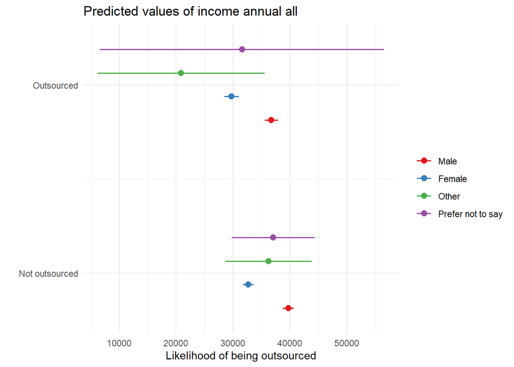

### 3.4.3 Demographic models

#### 3.4.3.1 Ethnicity

Several regressions were run to assess the likelihood of being outsourced from demographics. These models underlie the claims in the report in relation to ethnicity, migration, and gender.

The overall model was defined as:

$$Outsourcing = Ethnicity + Age + Gender + Education + Region + Migration$$

where

For this exploration we modelled ethnicity in three ways.

We used `svyglm()` from the `survey` package to construct survey-weighted generalised linear models. This approach allows us to take into account survey weights to produce design-based standard errors by assuming a ‘quasibinomial’ distribution to the data. Specifically, the survey-weighted data contains overdispersion; the variance is greater than expected by a binomial distribution (which assumes variance = mean(1 - mean)). The quasibinomial distribution estimates a dispersion parameter that allows the variance to be greater than expected by the true binomial distribution. For more information see Lumley, Thomas, and Alastair Scott. ‘Fitting Regression Models to Survey Data’. Statistical Science 32, no. 2 (2017): 265–780.

We used Rao–Scott adjusted Wald tests to compare nested survey-weighted models fit using a quasibinomial family. This method accounts for the survey design and is appropriate given that quasi-likelihood models do not support likelihood-ratio testing. For more information see Rao, J. N. K., and A. J. Scott. ‘On Chi-Squared Tests for Multiway Contingency Tables with Cell Proportions Estimated from Survey Data’. The Annals of Statistics 12, no. 1 (March 1984): 46–60. https://doi.org/10.1214/aos/1176346391.

For model 1, a saturated model including all variables was a significantly better fit to the data than an intercept-only model, *F*(29, 9782) = 8.72, *p* < .001. The table below shows the model coefficients.

|  | Outsourcing |  |  |
| --- | --- | --- | --- |
| Predictors | Odds Ratios | CI | p |
| Intercept | 0.65 | 0.49 – 0.86 | **0.002** |
| Ethnicity: Not White | 1.38 | 1.15 – 1.66 | **0.001** |
| Ethnicity: Don't think of myself as any of these | 2.50 | 0.76 – 8.18 | 0.131 |
| Ethnicity: Prefer not to say | 1.41 | 0.39 – 5.14 | 0.600 |
| Age | 0.98 | 0.97 – 0.98 | **<0.001** |
| Gender: Female | 0.69 | 0.61 – 0.79 | **<0.001** |
| Gender: Other | 0.87 | 0.22 – 3.50 | 0.842 |
| Gender: Prefer not to say | 0.82 | 0.26 – 2.53 | 0.724 |
| Education: Don't have degree | 1.06 | 0.93 – 1.21 | 0.372 |
| Education: Don't know | 1.14 | 0.64 – 2.04 | 0.650 |
| Region: East Midlands | 0.94 | 0.71 – 1.25 | 0.676 |
| Region: East of England | 0.59 | 0.44 – 0.79 | **0.001** |
| Region: North East | 0.63 | 0.44 – 0.91 | **0.012** |
| Region: North West | 0.85 | 0.66 – 1.08 | 0.185 |
| Region: Northern Ireland | 0.70 | 0.46 – 1.07 | 0.098 |
| Region: Scotland | 0.68 | 0.50 – 0.93 | **0.015** |
| Region: South East | 0.62 | 0.49 – 0.79 | **<0.001** |
| Region: South West | 0.68 | 0.52 – 0.90 | **0.006** |
| Region: Wales | 0.91 | 0.66 – 1.25 | 0.551 |
| Region: West Midlands | 0.83 | 0.65 – 1.08 | 0.166 |
| Region: Yorkshire and the Humber | 0.68 | 0.52 – 0.89 | **0.005** |
| Migration: Arrived within the last year | 1.69 | 1.13 – 2.52 | **0.010** |
| Migration: Arrived within the last 3 years | 1.03 | 0.68 – 1.56 | 0.885 |
| Migration: Arrived within the last 5 years | 1.22 | 0.78 – 1.89 | 0.386 |
| Migration: Arrived within the last 10 years | 1.61 | 1.14 – 2.26 | **0.006** |
| Migration: Arrived within the last 15 years | 1.58 | 1.05 – 2.36 | **0.026** |
| Migration: Arrived within the last 20 years | 1.54 | 1.00 – 2.35 | **0.048** |
| Migration: Arrived within the last 30 years | 0.45 | 0.22 – 0.92 | **0.029** |
| Migration: Arrived more than 30 years ago | 2.01 | 1.31 – 3.08 | **0.001** |
| Migration: Prefer not to say | 1.22 | 0.71 – 2.10 | 0.472 |
| Observations | 9812 |  |  |

For model 2, a saturated model including all variables was a significantly better fit to the data than an intercept-only model, *F*(34, 9777) = 8.07, *p* < .001. The table below shows the model coefficients.

|  | Outsourcing |  |  |
| --- | --- | --- | --- |
| Predictors | Odds Ratios | CI | p |
| Intercept | 0.67 | 0.50 – 0.88 | **0.004** |
| Ethnicity: Arab/British Arab | 1.98 | 0.77 – 5.11 | 0.159 |
| Ethnicity: Asian/Asian British | 1.24 | 0.96 – 1.59 | 0.094 |
| Ethnicity: Black/African/Caribbean/Black British | 1.47 | 1.10 – 1.96 | **0.010** |
| Ethnicity: Don't think of myself as any of these | 2.35 | 0.72 – 7.73 | 0.159 |
| Ethnicity: Mixed/Multiple ethnic group | 1.37 | 1.00 – 1.89 | 0.053 |
| Ethnicity: Other ethnic group | 1.03 | 0.27 – 4.01 | 0.963 |
| Ethnicity: Prefer not to say | 1.37 | 0.37 – 5.01 | 0.639 |
| Ethnicity: White other | 0.81 | 0.58 – 1.11 | 0.191 |
| Age | 0.98 | 0.97 – 0.98 | **<0.001** |
| Gender: Female | 0.69 | 0.61 – 0.78 | **<0.001** |
| Gender: Other | 0.88 | 0.21 – 3.62 | 0.860 |
| Gender: Prefer not to say | 0.81 | 0.26 – 2.50 | 0.711 |
| Education: Don't have degree | 1.06 | 0.93 – 1.21 | 0.357 |
| Education: Don't know | 1.16 | 0.65 – 2.06 | 0.618 |
| Region: East Midlands | 0.93 | 0.71 – 1.23 | 0.628 |
| Region: East of England | 0.58 | 0.43 – 0.78 | **<0.001** |
| Region: North East | 0.62 | 0.43 – 0.89 | **0.009** |
| Region: North West | 0.83 | 0.65 – 1.07 | 0.143 |
| Region: Northern Ireland | 0.72 | 0.47 – 1.10 | 0.129 |
| Region: Scotland | 0.67 | 0.50 – 0.91 | **0.011** |
| Region: South East | 0.61 | 0.48 – 0.78 | **<0.001** |
| Region: South West | 0.67 | 0.50 – 0.88 | **0.004** |
| Region: Wales | 0.89 | 0.65 – 1.22 | 0.476 |
| Region: West Midlands | 0.83 | 0.64 – 1.07 | 0.147 |
| Region: Yorkshire and the Humber | 0.67 | 0.51 – 0.88 | **0.004** |
| Migration: Arrived within the last year | 1.71 | 1.13 – 2.60 | **0.011** |
| Migration: Arrived within the last 3 years | 1.08 | 0.71 – 1.65 | 0.713 |
| Migration: Arrived within the last 5 years | 1.31 | 0.83 – 2.07 | 0.249 |
| Migration: Arrived within the last 10 years | 1.80 | 1.23 – 2.63 | **0.002** |
| Migration: Arrived within the last 15 years | 1.74 | 1.13 – 2.68 | **0.013** |
| Migration: Arrived within the last 20 years | 1.68 | 1.07 – 2.63 | **0.024** |
| Migration: Arrived within the last 30 years | 0.49 | 0.23 – 1.02 | 0.056 |
| Migration: Arrived more than 30 years ago | 2.09 | 1.36 – 3.22 | **0.001** |
| Migration: Prefer not to say | 1.24 | 0.72 – 2.14 | 0.430 |
| Observations | 9812 |  |  |

For model 3, a saturated model including all variables was a significantly better fit to the data than an intercept-only model, *F*(46, 9765) = 6.88, *p* < .001. The table below shows the model coefficients.

|  | Outsourcing |  |  |
| --- | --- | --- | --- |
| Predictors | Odds Ratios | CI | p |
| Intercept | 0.67 | 0.50 – 0.88 | **0.004** |
| Ethnicity: Irish | 0.76 | 0.40 – 1.45 | 0.410 |
| Ethnicity: Gypsy or Irish Traveller | 1.00 | 0.18 – 5.50 | 0.999 |
| Ethnicity: Roma | 1.25 | 0.32 – 4.87 | 0.751 |
| Ethnicity: Any other White background | 0.80 | 0.55 – 1.15 | 0.225 |
| Ethnicity: White and Black Caribbean | 0.49 | 0.25 – 0.95 | **0.035** |
| Ethnicity: White and Black African | 2.66 | 1.51 – 4.66 | **0.001** |
| Ethnicity: White and Asian | 1.19 | 0.58 – 2.46 | 0.634 |
| Ethnicity: Any other Mixed/Multiple ethnic background | 2.00 | 1.08 – 3.67 | **0.026** |
| Ethnicity: Indian | 1.18 | 0.81 – 1.71 | 0.396 |
| Ethnicity: Pakistani | 2.17 | 1.45 – 3.25 | **<0.001** |
| Ethnicity: Bangladeshi | 1.32 | 0.71 – 2.45 | 0.375 |
| Ethnicity: Chinese | 0.62 | 0.33 – 1.19 | 0.150 |
| Ethnicity: Any other Asian background | 1.19 | 0.70 – 2.04 | 0.521 |
| Ethnicity: African | 1.44 | 1.04 – 2.00 | **0.027** |
| Ethnicity: Caribbean | 1.27 | 0.63 – 2.54 | 0.499 |
| Ethnicity: Any other Black, Black British, or Caribbean background | 1.84 | 0.88 – 3.86 | 0.106 |
| Ethnicity: Arab | 1.97 | 0.76 – 5.10 | 0.164 |
| Ethnicity: Any other ethnic group | 1.03 | 0.26 – 4.03 | 0.963 |
| Ethnicity: Don't think of myself as any of these | 2.31 | 0.71 – 7.57 | 0.166 |
| Ethnicity: Prefer not to say | 1.37 | 0.37 – 5.04 | 0.632 |
| Age | 0.98 | 0.97 – 0.98 | **<0.001** |
| Gender: Female | 0.69 | 0.61 – 0.79 | **<0.001** |
| Gender: Other | 0.88 | 0.22 – 3.63 | 0.865 |
| Gender: Prefer not to say | 0.83 | 0.27 – 2.56 | 0.747 |
| Education: Don't have degree | 1.06 | 0.93 – 1.20 | 0.402 |
| Education: Don't know | 1.16 | 0.65 – 2.06 | 0.623 |
| Region: East Midlands | 0.92 | 0.70 – 1.22 | 0.583 |
| Region: East of England | 0.57 | 0.42 – 0.77 | **<0.001** |
| Region: North East | 0.61 | 0.43 – 0.88 | **0.008** |
| Region: North West | 0.81 | 0.63 – 1.05 | 0.111 |
| Region: Northern Ireland | 0.73 | 0.46 – 1.14 | 0.165 |
| Region: Scotland | 0.67 | 0.49 – 0.91 | **0.009** |
| Region: South East | 0.60 | 0.48 – 0.77 | **<0.001** |
| Region: South West | 0.66 | 0.50 – 0.87 | **0.003** |
| Region: Wales | 0.88 | 0.64 – 1.21 | 0.423 |
| Region: West Midlands | 0.81 | 0.62 – 1.05 | 0.104 |
| Region: Yorkshire and the Humber | 0.65 | 0.50 – 0.86 | **0.002** |
| Migration: Arrived within the last year | 1.76 | 1.14 – 2.72 | **0.011** |
| Migration: Arrived within the last 3 years | 1.10 | 0.72 – 1.69 | 0.652 |
| Migration: Arrived within the last 5 years | 1.23 | 0.77 – 1.97 | 0.389 |
| Migration: Arrived within the last 10 years | 1.76 | 1.20 – 2.57 | **0.004** |
| Migration: Arrived within the last 15 years | 1.84 | 1.18 – 2.87 | **0.007** |
| Migration: Arrived within the last 20 years | 1.69 | 1.07 – 2.66 | **0.024** |
| Migration: Arrived within the last 30 years | 0.49 | 0.24 – 1.01 | 0.054 |
| Migration: Arrived more than 30 years ago | 2.11 | 1.37 – 3.26 | **0.001** |
| Migration: Prefer not to say | 1.22 | 0.70 – 2.12 | 0.478 |
| Observations | 9812 |  |  |

#### 3.4.3.2 Migration

We next focus on predicting whether a person was outsourced based on wehther the person was born in the UK. This binary variable was constructed by collapsing the 10-level migration variable down into two levels, so that “I was born in the UK” becomes “Born in UK”, and all levels apart from “I was born in the UK” and “Prefer not to say” become “Not born in UK”.

A saturated model including all variables was a significantly better fit to the data than an intercept-only model, *F*(39, 9772) = 7.52, *p* < .001. The table below shows the model coefficients.

|  | Outsourcing |  |  |
| --- | --- | --- | --- |
| Predictors | Odds Ratios | CI | p |
| Intercept | 0.66 | 0.50 – 0.88 | **0.004** |
| Migration: Not born in the UK | 1.52 | 1.22 – 1.89 | **<0.001** |
| Migration: Prefer not to say | 1.23 | 0.71 – 2.13 | 0.465 |
| Ethnicity: Irish | 0.76 | 0.40 – 1.44 | 0.396 |
| Ethnicity: Gypsy or Irish Traveller | 1.04 | 0.20 – 5.55 | 0.962 |
| Ethnicity: Roma | 1.11 | 0.26 – 4.73 | 0.883 |
| Ethnicity: Any other White background | 0.82 | 0.57 – 1.16 | 0.253 |
| Ethnicity: White and Black Caribbean | 0.48 | 0.25 – 0.94 | **0.033** |
| Ethnicity: White and Black African | 2.56 | 1.45 – 4.54 | **0.001** |
| Ethnicity: White and Asian | 1.22 | 0.58 – 2.57 | 0.595 |
| Ethnicity: Any other Mixed/Multiple ethnic background | 1.81 | 1.04 – 3.16 | **0.037** |
| Ethnicity: Indian | 1.13 | 0.77 – 1.65 | 0.530 |
| Ethnicity: Pakistani | 2.13 | 1.40 – 3.22 | **<0.001** |
| Ethnicity: Bangladeshi | 1.27 | 0.68 – 2.37 | 0.457 |
| Ethnicity: Chinese | 0.60 | 0.31 – 1.15 | 0.125 |
| Ethnicity: Any other Asian background | 1.21 | 0.72 – 2.04 | 0.480 |
| Ethnicity: African | 1.46 | 1.08 – 1.98 | **0.014** |
| Ethnicity: Caribbean | 1.24 | 0.61 – 2.51 | 0.545 |
| Ethnicity: Any other Black, Black British, or Caribbean background | 1.73 | 0.83 – 3.64 | 0.146 |
| Ethnicity: Arab | 2.04 | 0.80 – 5.22 | 0.136 |
| Ethnicity: Any other ethnic group | 1.04 | 0.27 – 4.01 | 0.951 |
| Ethnicity: Don't think of myself as any of these | 2.28 | 0.71 – 7.27 | 0.164 |
| Ethnicity: Prefer not to say | 1.29 | 0.35 – 4.77 | 0.704 |
| Age | 0.98 | 0.97 – 0.98 | **<0.001** |
| Gender: Female | 0.70 | 0.61 – 0.79 | **<0.001** |
| Gender: Other | 0.88 | 0.22 – 3.62 | 0.865 |
| Gender: Prefer not to say | 0.82 | 0.27 – 2.54 | 0.737 |
| Education: Don't have degree | 1.05 | 0.93 – 1.20 | 0.420 |
| Education: Don't know | 1.19 | 0.67 – 2.11 | 0.561 |
| Region: East Midlands | 0.93 | 0.70 – 1.23 | 0.598 |
| Region: East of England | 0.56 | 0.42 – 0.76 | **<0.001** |
| Region: North East | 0.61 | 0.42 – 0.88 | **0.007** |
| Region: North West | 0.81 | 0.63 – 1.04 | 0.100 |
| Region: Northern Ireland | 0.72 | 0.46 – 1.13 | 0.157 |
| Region: Scotland | 0.66 | 0.49 – 0.90 | **0.008** |
| Region: South East | 0.60 | 0.47 – 0.76 | **<0.001** |
| Region: South West | 0.66 | 0.50 – 0.87 | **0.003** |
| Region: Wales | 0.87 | 0.64 – 1.20 | 0.403 |
| Region: West Midlands | 0.80 | 0.62 – 1.04 | 0.098 |
| Region: Yorkshire and the Humber | 0.65 | 0.49 – 0.85 | **0.002** |
| Observations | 9812 |  |  |

#### 3.4.3.3 Gender

We used the same generalised linear model as in the previous section to estimate the effect of Gender on outsourcing, where Gender is a categorical variable with four levels:

- Male (reference category)
- Female
- Prefer not to say
- Other

The model indicates that women are 0.7 times as likely (i.e. 30% less likely) to be outsourced than men.

#### 3.4.3.4 Age

Again using the same model, we found that age was a significant predictor of the likelihood of being outsourced. The model indicates that for each year older a worker is, they are 0.98 times as likely (i.e. 2% less likely) to be outsourced.

We also explored how age predicted whether a person was on low pay. The model formula is:

$$Income Group = Age + Outsourcing + Ethnicity + Gender + Education + Region + Migration$$

A saturated model including all variables was a significantly better fit to the data than an intercept-only model, *X^2*(80) = 22488.5220048, *p* < .001. The table below shows the model coefficients.

| income_group | estimate | std.error | statistic | p.value | conf.low | conf.high | sig |
| --- | --- | --- | --- | --- | --- | --- | --- |
| **Mid** |  |  |  |  |  |  |  |
| (Intercept) | 7.479 | 0.171 | 11.740 | 0.000 | 5.345 | 10.464 | *** |
| Age | 0.993 | 0.003 | -2.637 | 0.008 | 0.988 | 0.998 | ** |
| outsourcing_statusOutsourced | 0.734 | 0.088 | -3.504 | 0.000 | 0.617 | 0.873 | *** |
| Ethnicity_collapsed_disaggregatedIrish | 0.742 | 0.297 | -1.003 | 0.316 | 0.415 | 1.329 |  |
| Ethnicity_collapsed_disaggregatedGypsy or Irish Traveller | 3.960 | 1.063 | 1.295 | 0.195 | 0.493 | 31.793 |  |
| Ethnicity_collapsed_disaggregatedRoma | 2690728.949 | 0.211 | 70.286 | 0.000 | 1780611.541 | 4066031.311 | *** |
| Ethnicity_collapsed_disaggregatedAny other White background | 0.969 | 0.195 | -0.163 | 0.870 | 0.660 | 1.421 |  |
| Ethnicity_collapsed_disaggregatedWhite and Black Caribbean | 0.815 | 0.337 | -0.609 | 0.543 | 0.421 | 1.576 |  |
| Ethnicity_collapsed_disaggregatedWhite and Black African | 1.030 | 0.460 | 0.064 | 0.949 | 0.418 | 2.537 |  |
| Ethnicity_collapsed_disaggregatedWhite and Asian | 0.565 | 0.324 | -1.765 | 0.077 | 0.300 | 1.065 |  |
| Ethnicity_collapsed_disaggregatedAny other Mixed / Multiple ethnic background | 0.525 | 0.332 | -1.940 | 0.052 | 0.273 | 1.007 |  |
| Ethnicity_collapsed_disaggregatedIndian | 1.190 | 0.228 | 0.761 | 0.446 | 0.761 | 1.860 |  |
| Ethnicity_collapsed_disaggregatedPakistani | 0.761 | 0.249 | -1.092 | 0.275 | 0.467 | 1.242 |  |
| Ethnicity_collapsed_disaggregatedBangladeshi | 0.620 | 0.378 | -1.262 | 0.207 | 0.295 | 1.302 |  |
| Ethnicity_collapsed_disaggregatedChinese | 1.393 | 0.362 | 0.916 | 0.360 | 0.685 | 2.830 |  |
| Ethnicity_collapsed_disaggregatedAny other Asian background | 0.790 | 0.360 | -0.656 | 0.512 | 0.390 | 1.599 |  |
| Ethnicity_collapsed_disaggregatedAfrican | 0.803 | 0.198 | -1.110 | 0.267 | 0.544 | 1.184 |  |
| Ethnicity_collapsed_disaggregatedCaribbean | 1.067 | 0.396 | 0.163 | 0.870 | 0.491 | 2.316 |  |
| Ethnicity_collapsed_disaggregatedAny other Black, Black British, or Caribbean background | 0.837 | 0.475 | -0.376 | 0.707 | 0.330 | 2.121 |  |
| Ethnicity_collapsed_disaggregatedArab | 0.583 | 0.661 | -0.816 | 0.415 | 0.160 | 2.130 |  |
| Ethnicity_collapsed_disaggregatedAny other ethnic group | 1.590 | 1.158 | 0.401 | 0.689 | 0.164 | 15.376 |  |
| Ethnicity_collapsed_disaggregatedDon’t think of myself as any of these | 2.858 | 0.897 | 1.171 | 0.241 | 0.493 | 16.566 |  |
| Ethnicity_collapsed_disaggregatedPrefer not to say | 0.597 | 0.647 | -0.799 | 0.424 | 0.168 | 2.119 |  |
| GenderFemale | 0.363 | 0.071 | -14.266 | 0.000 | 0.316 | 0.417 | *** |
| GenderOther | 0.253 | 0.663 | -2.071 | 0.038 | 0.069 | 0.929 | * |
| GenderPrefer not to say | 0.494 | 0.841 | -0.838 | 0.402 | 0.095 | 2.568 |  |
| Has_DegreeNo | 0.523 | 0.067 | -9.684 | 0.000 | 0.459 | 0.596 | *** |
| Has_DegreeDon't know | 0.325 | 0.304 | -3.693 | 0.000 | 0.179 | 0.591 | *** |
| RegionEast Midlands | 0.904 | 0.153 | -0.662 | 0.508 | 0.670 | 1.219 |  |

[output cut: 54 more lines]

#### 3.4.3.5 Ethnicity-migration interaction

We next explored whether there was an interaction between ethnicity and migration in predicting outsourcing using generalised linear models by adding an interaction effect to the model predicting outsourcing above so that the model formula is:

$$Outsourcing = Ethnicity + Age + Gender + Educaton + Region + Migration + Ethnicity:Migration$$

where Ethnicity:Migration represents the interaction term.

##### 3.4.3.5.1 Ethnicity 9

A model including the ethnicity:migration interaction term had significantly improved fit compared to a model without the interaction term, *F*(13, 9771) = 33.88, *p* < .001. The table below shows the model coefficients.

|  | Outsourcing |  |  |
| --- | --- | --- | --- |
| Predictors | Odds Ratios | CI | p |
| Intercept | 0.62 | 0.47 – 0.82 | **0.001** |
| Migration: Not born in the UK | 2.16 | 1.60 – 2.91 | **<0.001** |
| Migration: Prefer not to say | 1.88 | 0.94 – 3.79 | 0.076 |
| Ethnicity: Arab/British Arab | 1.86 | 0.39 – 8.76 | 0.435 |
| Ethnicity: Asian/Asian British | 1.48 | 1.09 – 2.00 | **0.011** |
| Ethnicity: Black/African/Caribbean/Black British | 1.53 | 1.00 – 2.35 | **0.049** |
| Ethnicity: Don't think of myself as any of these | 5.49 | 1.00 – 30.12 | **0.050** |
| Ethnicity: Mixed/Multiple ethnic group | 1.16 | 0.81 – 1.67 | 0.406 |
| Ethnicity: Other ethnic group | 3.35 | 0.65 – 17.23 | 0.147 |
| Ethnicity: Prefer not to say | 1.99 | 0.44 – 8.97 | 0.369 |
| Ethnicity: White other | 1.06 | 0.64 – 1.74 | 0.825 |
| Age | 0.98 | 0.97 – 0.98 | **<0.001** |
| Gender: Female | 0.69 | 0.61 – 0.79 | **<0.001** |
| Gender: Other | 0.88 | 0.22 – 3.52 | 0.857 |
| Gender: Prefer not to say | 0.75 | 0.23 – 2.45 | 0.636 |
| Education: Don't have degree | 1.06 | 0.94 – 1.21 | 0.341 |
| Education: Don't know | 1.24 | 0.70 – 2.20 | 0.467 |
| Region: East Midlands | 0.95 | 0.72 – 1.26 | 0.744 |
| Region: East of England | 0.59 | 0.44 – 0.80 | **0.001** |
| Region: North East | 0.64 | 0.44 – 0.91 | **0.015** |
| Region: North West | 0.85 | 0.66 – 1.10 | 0.209 |
| Region: Northern Ireland | 0.69 | 0.44 – 1.08 | 0.106 |
| Region: Scotland | 0.69 | 0.51 – 0.94 | **0.020** |
| Region: South East | 0.62 | 0.49 – 0.79 | **<0.001** |
| Region: South West | 0.69 | 0.52 – 0.91 | **0.009** |
| Region: Wales | 0.92 | 0.67 – 1.26 | 0.597 |
| Region: West Midlands | 0.83 | 0.64 – 1.08 | 0.159 |
| Region: Yorkshire and the Humber | 0.68 | 0.52 – 0.90 | **0.007** |
| Interaction: Not born in UK x Arab/Arab British | 0.86 | 0.12 – 6.12 | 0.881 |
| Interaction: Not born in UK x Asian/Asian British | 0.52 | 0.32 – 0.87 | **0.012** |
| Interaction: Prefer not to say x Asian/Asian British | 0.26 | 0.05 – 1.27 | 0.096 |
| Interaction: Not born in UK x Black/African/Caribbean/Black British | 0.66 | 0.37 – 1.18 | 0.161 |
| Interaction: Prefer not to say x Black/African/Caribbean/Black British | 0.97 | 0.23 – 3.99 | 0.964 |
| Interaction: Not born in UK x Don't think of myself as any of these | 0.13 | 0.01 – 1.80 | 0.128 |
| Interaction: Not born in UK x Mixed/Multiple ethnic group | 1.27 | 0.60 – 2.70 | 0.530 |
| Interaction: Prefer not to say x Mixed/Multiple ethnic group | 0.39 | 0.03 – 4.64 | 0.453 |
| Interaction: Not born in UK x Other ethnic group | 0.00 | 0.00 – 0.00 | **<0.001** |
| Interaction: Not born in UK x Prefer not to say | 0.49 | 0.04 – 5.99 | 0.577 |
| Interaction: Prefer not to say x Prefer not to say | 0.00 | 0.00 – 0.00 | **<0.001** |
| Interaction: Not born in UK x White other | 0.53 | 0.28 – 1.01 | 0.053 |
| Interaction: Prefer not to say x White other | 0.59 | 0.10 – 3.61 | 0.564 |
| Observations | 9812 |  |  |

###### 3.4.3.5.1.1 Post-hoc

We explored the interaction effect using targeted contrasts comparing

1. The effect of each ethnicity versus “White British” within each level of migration.
2. The effect of “Not born in UK” versus “Born in UK” within each level of ethnicity

Contrasts were calculated using `survey::svycontrast()` and p values were adjusted for multiple comparisons using the FDR method (Benjamini and Hochberg, 1995). Results were only considered where the sample for the contrast was greater than 10.

Exploring the effect of each ethnicity versus “White British” within each level of migration, we found that, among people not born in the UK, White other workers were 0.56 times as likely (i.e., 44% less likely) to be outsourced than “White British” people.

No differences by ethnicity were observed among people born in the UK.

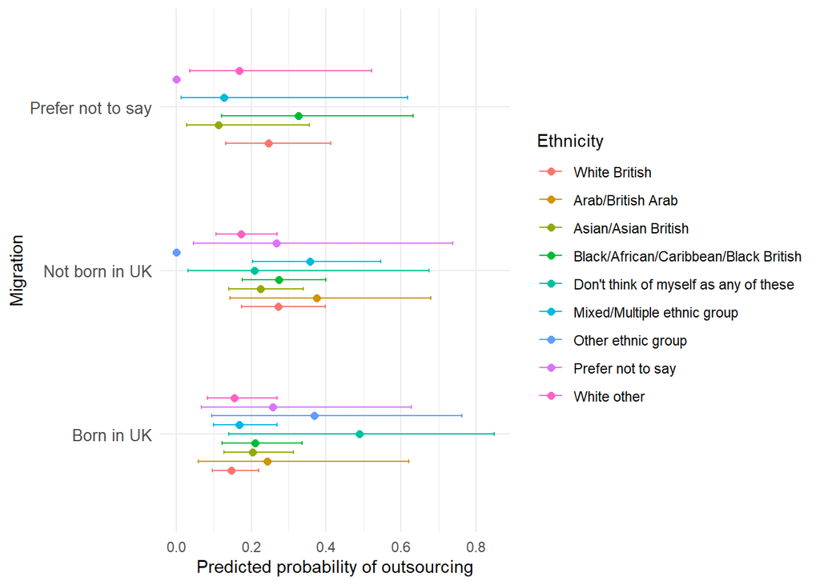

Examining the effect of “Not born in UK” versus “Born in UK” within each ethnicity, we found

- among “White British”, workers not born in the UK are 2.16 times more likely to be outsourced than workers born in the UK.
- among people of Mixed/multiple ethnic groups, workers not born in UK are 2.74 times more likely to be outsourced than workers born in the UK.

No significant differences between people born and not born in the UK were observed for any other ethnicities. The figure below shows these effects.

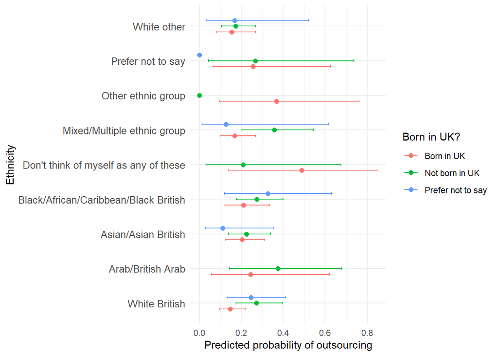

##### 3.4.3.5.2 Ethnicity 21

A model including the ethnicity:migration interaction term had significantly improved fit compared to a model without the interaction term, *F*(32, 9740) = 64.66, *p* < .001. The table below shows the model coefficients.

Note: Migration x Roma not estimable as model matrix rank deficient

|  | Outsourcing |  |  |
| --- | --- | --- | --- |
| Predictors | Odds Ratios | CI | p |
| Intercept | 0.63 | 0.47 – 0.83 | **0.001** |
| Migration: Not born in the UK | 2.15 | 1.59 – 2.90 | **<0.001** |
| Migration: Prefer not to say | 1.89 | 0.94 – 3.79 | 0.075 |
| Ethnicity: Irish | 0.93 | 0.44 – 1.96 | 0.846 |
| Ethnicity: Gypsy or Irish Traveller | 1.67 | 0.31 – 8.85 | 0.547 |
| Ethnicity: Roma | 0.81 | 0.19 – 3.49 | 0.775 |
| Ethnicity: Any other White background | 1.11 | 0.55 – 2.26 | 0.769 |
| Ethnicity: White and Black Caribbean | 0.53 | 0.27 – 1.04 | 0.066 |
| Ethnicity: White and Black African | 3.38 | 1.68 – 6.82 | **0.001** |
| Ethnicity: White and Asian | 0.90 | 0.37 – 2.19 | 0.817 |
| Ethnicity: Any other Mixed/Multiple ethnic background | 1.87 | 0.96 – 3.65 | 0.067 |
| Ethnicity: Indian | 1.32 | 0.80 – 2.19 | 0.280 |
| Ethnicity: Pakistani | 2.67 | 1.68 – 4.25 | **<0.001** |
| Ethnicity: Bangladeshi | 1.81 | 0.84 – 3.86 | 0.128 |
| Ethnicity: Chinese | 0.53 | 0.16 – 1.74 | 0.299 |
| Ethnicity: Any other Asian background | 1.06 | 0.36 – 3.11 | 0.916 |
| Ethnicity: African | 1.52 | 0.87 – 2.64 | 0.140 |
| Ethnicity: Caribbean | 1.12 | 0.49 – 2.53 | 0.787 |
| Ethnicity: Any other Black, Black British, or Caribbean background | 2.60 | 1.05 – 6.41 | **0.038** |
| Ethnicity: Arab | 1.85 | 0.39 – 8.69 | 0.435 |
| Ethnicity: Any other ethnic group | 3.34 | 0.65 – 17.32 | 0.150 |
| Ethnicity: Don't think of myself as any of these | 5.43 | 1.00 – 29.50 | **0.050** |
| Ethnicity: Prefer not to say | 1.99 | 0.44 – 8.97 | 0.370 |
| Age | 0.98 | 0.97 – 0.98 | **<0.001** |
| Gender: Female | 0.69 | 0.61 – 0.79 | **<0.001** |
| Gender: Other | 0.87 | 0.22 – 3.44 | 0.846 |
| Gender: Prefer not to say | 0.77 | 0.24 – 2.50 | 0.662 |
| Education: Don't have degree | 1.06 | 0.93 – 1.20 | 0.405 |
| Education: Don't know | 1.21 | 0.67 – 2.18 | 0.519 |
| Region: East Midlands | 0.94 | 0.71 – 1.25 | 0.692 |
| Region: East of England | 0.59 | 0.44 – 0.80 | **0.001** |
| Region: North East | 0.63 | 0.44 – 0.91 | **0.014** |
| Region: North West | 0.84 | 0.65 – 1.08 | 0.179 |
| Region: Northern Ireland | 0.71 | 0.44 – 1.14 | 0.153 |
| Region: Scotland | 0.69 | 0.50 – 0.93 | **0.017** |
| Region: South East | 0.62 | 0.49 – 0.79 | **<0.001** |
| Region: South West | 0.68 | 0.51 – 0.90 | **0.007** |
| Region: Wales | 0.90 | 0.65 – 1.24 | 0.524 |
| Region: West Midlands | 0.80 | 0.61 – 1.04 | 0.093 |
| Region: Yorkshire and the Humber | 0.67 | 0.51 – 0.88 | **0.004** |
| Interaction: Not born in UK x Irish | 0.28 | 0.07 – 1.19 | 0.085 |
| Interaction: Prefer not to say x Irish | 1.31 | 0.09 – 18.48 | 0.842 |
| Interaction: Not born in UK x Gypsy or Irish Traveller | 0.00 | 0.00 – 0.00 | **<0.001** |
| Interaction: Not born in UK x Any other White background | 0.52 | 0.23 – 1.18 | 0.118 |
| Interaction: Prefer not to say x Any other White background | 0.38 | 0.04 – 3.92 | 0.413 |
| Interaction: Not born in UK x White and Black Caribbean | 0.00 | 0.00 – 0.00 | **<0.001** |
| Interaction: Prefer not to say x White and Black Caribbean | 0.00 | 0.00 – 0.00 | **<0.001** |
| Interaction: Not born in UK x White and Black African | 0.46 | 0.14 – 1.52 | 0.203 |
| Interaction: Prefer not to say x White and Black African | 0.00 | 0.00 – 0.00 | **<0.001** |
| Interaction: Not born in UK x White and Asian | 2.76 | 0.48 – 15.70 | 0.253 |
| Interaction: Not born in UK x Any other Mixed/Multiple ethnic background | 0.69 | 0.21 – 2.26 | 0.541 |
| Interaction: Prefer not to say x Any other Mixed/Multiple ethnic background | 1.10 | 0.03 – 41.99 | 0.960 |
| Interaction: Not born in UK x Indian | 0.55 | 0.26 – 1.17 | 0.120 |
| Interaction: Prefer not to say x Indian | 0.38 | 0.04 – 3.31 | 0.380 |
| Interaction: Not born in UK x Pakistani | 0.43 | 0.17 – 1.09 | 0.074 |
| Interaction: Prefer not to say x Pakistani | 0.00 | 0.00 – 0.00 | **<0.001** |
| Interaction: Not born in UK x Bangladeshi | 0.38 | 0.10 – 1.48 | 0.162 |
| Interaction: Prefer not to say x Bangladeshi | 0.30 | 0.03 – 2.99 | 0.305 |
| Interaction: Not born in UK x Chinese | 0.88 | 0.21 – 3.70 | 0.864 |
| Interaction: Not born in UK x Any other Asian background | 0.90 | 0.26 – 3.13 | 0.864 |
| Interaction: Prefer not to say x Any other Asian background | 0.00 | 0.00 – 0.00 | **<0.001** |
| Interaction: Not born in UK x African | 0.69 | 0.35 – 1.36 | 0.278 |
| Interaction: Prefer not to say x African | 0.89 | 0.19 – 4.18 | 0.886 |
| Interaction: Not born in UK x Caribbean | 0.84 | 0.14 – 5.19 | 0.851 |
| Interaction: Prefer not to say x Caribbean | 8523821.18 | 897250.55 – 80975740.17 | **<0.001** |
| Interaction: Not born in UK x Any other Black, Black British, or Caribbean background | 0.25 | 0.05 – 1.15 | 0.075 |
| Interaction: Prefer not to say x Any other Black, Black British, or Caribbean background | 0.00 | 0.00 – 0.00 | **<0.001** |
| Interaction: Not born in UK x Arab | 0.86 | 0.12 – 6.11 | 0.880 |
| Interaction: Not born in UK x Any other ethnic group | 0.00 | 0.00 – 0.00 | **<0.001** |
| Interaction: Not born in UK x Don't think of myself as any of these | 0.13 | 0.01 – 1.82 | 0.129 |
| Interaction: Not born in UK x Prefer not to say | 0.49 | 0.04 – 5.98 | 0.579 |
| Interaction: Prefer not to say x Prefer not to say | 0.00 | 0.00 – 0.00 | **<0.001** |
| Observations | 9812 |  |  |

###### 3.4.3.5.2.1 Post-hoc

We explored the interaction effect using targeted contrasts comparing

1. The effect of each ethnicity versus “English / Welsh / Scottish / Northern Irish / British” within each level of migration.
2. The effect of “Not born in UK” versus “Born in UK” within each level of ethnicity

Contrasts were calculated using survey::svycontrast() and p values were adjusted for multiple comparisons using the FDR method (Benjamini and Hochberg, 1995) and results were only considered where the sample for the contrast was greater than 10.

Exploring the effect of each ethnicity versus “English / Welsh / Scottish / Northern Irish / British” within each level of migration, we found that, among people born in the UK

- White and Black African people were 3.38 times more likely to be outsourced than “English / Welsh / Scottish / Northern Irish / British” people.
- Pakistani people were 2.67 times more likely to be outsourced than “English / Welsh / Scottish / Northern Irish / British” people.

Among people not born in the UK, no significant differences between ethnicities were observed. The figure below shows the effects for “English / Welsh / Scottish / Northern Irish / British”, “White and Black African”, and Pakistani respondents.

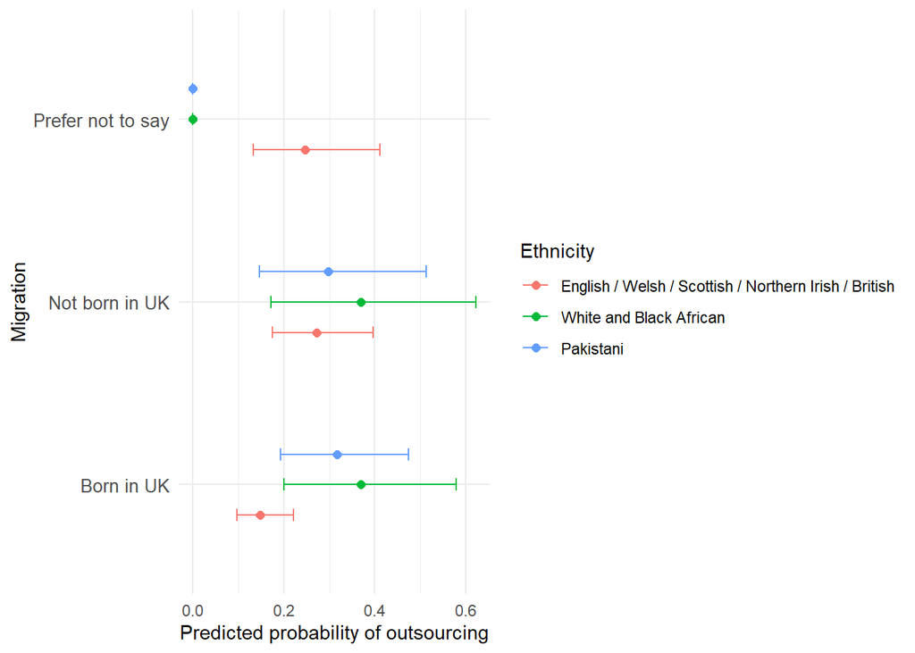

Examining the effect of “Not born in UK” versus “Born in UK” within each level of ethnicity, we found that among “English / Welsh / Scottish / Northern Irish / British”, workers not born in the UK are 2.15 times more likely to be outsourced than workers born in the UK.

No significant differences between people born and not born in the UK were observed for any other ethnicities. The figure below shows these effects.

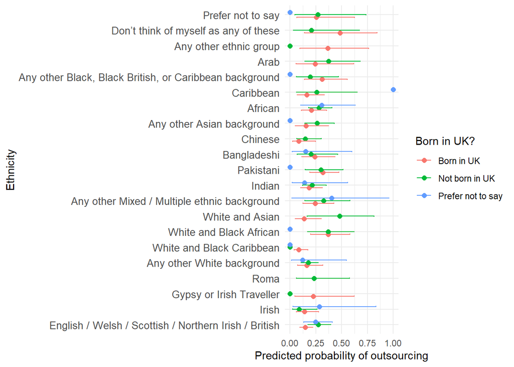

#### 3.4.3.6 Ethnicity-outsourced interaction

A generalised linear model was constructed to test whether the interaction between ethnicity and outsourcing predicted whether a person had a low income.

$$Income Group = Outsourcing + Ethnicity + Age + Gender + Education + Region + Migration + Outsourcing:Ethnicity$$

##### 3.4.3.6.1 Ethnicity binary

| income_group | estimate | std.error | statistic | p.value | conf.low | conf.high | sig |
| --- | --- | --- | --- | --- | --- | --- | --- |
| **Mid** |  |  |  |  |  |  |  |
| (Intercept) | 7.409 | 0.172 | 11.675 | 0.000 | 5.294 | 10.370 | *** |
| outsourcing_statusOutsourced | 0.722 | 0.098 | -3.332 | 0.001 | 0.596 | 0.875 | *** |
| Ethnicity_binaryNon-White | 0.904 | 0.128 | -0.787 | 0.432 | 0.704 | 1.162 |  |
| Age | 0.993 | 0.003 | -2.666 | 0.008 | 0.988 | 0.998 | ** |
| GenderFemale | 0.363 | 0.071 | -14.279 | 0.000 | 0.316 | 0.417 | *** |
| GenderOther | 0.254 | 0.664 | -2.065 | 0.039 | 0.069 | 0.933 | * |
| GenderPrefer not to say | 0.484 | 0.845 | -0.859 | 0.391 | 0.092 | 2.535 |  |
| Has_DegreeNo | 0.521 | 0.067 | -9.770 | 0.000 | 0.457 | 0.594 | *** |
| Has_DegreeDon't know | 0.309 | 0.309 | -3.803 | 0.000 | 0.169 | 0.566 | *** |
| RegionEast Midlands | 0.929 | 0.152 | -0.485 | 0.628 | 0.689 | 1.252 |  |
| RegionEast of England | 0.907 | 0.158 | -0.616 | 0.538 | 0.666 | 1.236 |  |
| RegionNorth East | 1.217 | 0.191 | 1.025 | 0.305 | 0.836 | 1.770 |  |
| RegionNorth West | 1.358 | 0.145 | 2.114 | 0.035 | 1.023 | 1.803 | * |
| RegionNorthern Ireland | 0.864 | 0.208 | -0.703 | 0.482 | 0.575 | 1.298 |  |
| RegionScotland | 0.913 | 0.157 | -0.579 | 0.563 | 0.671 | 1.242 |  |
| RegionSouth East | 1.028 | 0.132 | 0.209 | 0.834 | 0.793 | 1.333 |  |
| RegionSouth West | 1.130 | 0.147 | 0.827 | 0.408 | 0.846 | 1.508 |  |
| RegionWales | 1.540 | 0.192 | 2.243 | 0.025 | 1.056 | 2.245 | * |
| RegionWest Midlands | 1.104 | 0.144 | 0.685 | 0.493 | 0.832 | 1.465 |  |
| RegionYorkshire and the Humber | 1.102 | 0.149 | 0.656 | 0.512 | 0.824 | 1.475 |  |
| BORNUK_labelledWithin the last year | 0.726 | 0.247 | -1.297 | 0.195 | 0.448 | 1.178 |  |
| BORNUK_labelledWithin the last 3 years | 1.114 | 0.244 | 0.444 | 0.657 | 0.691 | 1.796 |  |
| BORNUK_labelledWithin the last 5 years | 0.999 | 0.267 | -0.005 | 0.996 | 0.592 | 1.684 |  |
| BORNUK_labelledWithin the last 10 years | 1.079 | 0.221 | 0.344 | 0.731 | 0.700 | 1.662 |  |
| BORNUK_labelledWithin the last 15 years | 1.098 | 0.253 | 0.369 | 0.712 | 0.668 | 1.804 |  |
| BORNUK_labelledWithin the last 20 years | 1.195 | 0.244 | 0.730 | 0.466 | 0.741 | 1.928 |  |
| BORNUK_labelledWithin the last 30 years | 1.617 | 0.428 | 1.122 | 0.262 | 0.698 | 3.745 |  |
| BORNUK_labelledMore than 30 years ago | 1.115 | 0.265 | 0.411 | 0.681 | 0.664 | 1.873 |  |
| BORNUK_labelledPrefer not to say | 0.449 | 0.430 | -1.862 | 0.063 | 0.193 | 1.043 |  |
| outsourcing_statusOutsourced:Ethnicity_binaryNon-White | 1.108 | 0.221 | 0.466 | 0.641 | 0.719 | 1.708 |  |
| **High** |  |  |  |  |  |  |  |
| (Intercept) | 3.852 | 0.204 | 6.611 | 0.000 | 2.582 | 5.745 | *** |
| outsourcing_statusOutsourced | 0.460 | 0.123 | -6.307 | 0.000 | 0.362 | 0.586 | *** |
| Ethnicity_binaryNon-White | 0.863 | 0.146 | -1.008 | 0.314 | 0.648 | 1.150 |  |
| Age | 1.003 | 0.003 | 0.922 | 0.357 | 0.997 | 1.009 |  |
| GenderFemale | 0.180 | 0.082 | -20.767 | 0.000 | 0.153 | 0.212 | *** |
| GenderOther | 0.284 | 0.852 | -1.478 | 0.139 | 0.053 | 1.507 |  |
| GenderPrefer not to say | 0.452 | 0.885 | -0.897 | 0.370 | 0.080 | 2.561 |  |
| Has_DegreeNo | 0.157 | 0.083 | -22.218 | 0.000 | 0.133 | 0.185 | *** |
| Has_DegreeDon't know | 0.154 | 0.375 | -4.991 | 0.000 | 0.074 | 0.321 | *** |
| RegionEast Midlands | 1.479 | 0.187 | 2.093 | 0.036 | 1.025 | 2.133 | * |
| RegionEast of England | 1.666 | 0.191 | 2.665 | 0.008 | 1.145 | 2.425 | ** |
| RegionNorth East | 1.869 | 0.230 | 2.725 | 0.006 | 1.192 | 2.931 | ** |
| RegionNorth West | 2.010 | 0.179 | 3.908 | 0.000 | 1.416 | 2.853 | *** |
| RegionNorthern Ireland | 1.344 | 0.269 | 1.101 | 0.271 | 0.794 | 2.277 |  |
| RegionScotland | 0.905 | 0.196 | -0.508 | 0.611 | 0.616 | 1.330 |  |
| RegionSouth East | 1.446 | 0.168 | 2.192 | 0.028 | 1.040 | 2.012 | * |
| RegionSouth West | 1.377 | 0.188 | 1.701 | 0.089 | 0.952 | 1.992 |  |
| RegionWales | 1.885 | 0.228 | 2.784 | 0.005 | 1.206 | 2.944 | ** |
| RegionWest Midlands | 1.575 | 0.184 | 2.473 | 0.013 | 1.099 | 2.257 | * |
| RegionYorkshire and the Humber | 1.435 | 0.191 | 1.893 | 0.058 | 0.987 | 2.085 |  |
| BORNUK_labelledWithin the last year | 0.235 | 0.390 | -3.716 | 0.000 | 0.109 | 0.504 | *** |
| BORNUK_labelledWithin the last 3 years | 0.547 | 0.327 | -1.847 | 0.065 | 0.288 | 1.038 |  |
| BORNUK_labelledWithin the last 5 years | 0.759 | 0.308 | -0.898 | 0.369 | 0.415 | 1.387 |  |
| BORNUK_labelledWithin the last 10 years | 0.814 | 0.267 | -0.770 | 0.441 | 0.482 | 1.374 |  |
| BORNUK_labelledWithin the last 15 years | 1.106 | 0.295 | 0.341 | 0.733 | 0.620 | 1.971 |  |
| BORNUK_labelledWithin the last 20 years | 1.191 | 0.294 | 0.594 | 0.552 | 0.669 | 2.118 |  |
| BORNUK_labelledWithin the last 30 years | 1.141 | 0.460 | 0.286 | 0.775 | 0.463 | 2.808 |  |
| BORNUK_labelledMore than 30 years ago | 1.199 | 0.278 | 0.652 | 0.514 | 0.695 | 2.069 |  |
| BORNUK_labelledPrefer not to say | 0.631 | 0.624 | -0.737 | 0.461 | 0.186 | 2.145 |  |
| outsourcing_statusOutsourced:Ethnicity_binaryNon-White | 1.290 | 0.266 | 0.957 | 0.338 | 0.766 | 2.172 |  |

##### 3.4.3.6.2 Ethnicity 9

A model including the ethnicity:outsourcing interaction term significantly improved model fit compared to a model without the interaction term, *X^2*(12) = 238.2925363, *p* < .001. The table below shows the model coefficients.

| income_group | estimate | std.error | statistic | p.value | conf.low | conf.high | sig |
| --- | --- | --- | --- | --- | --- | --- | --- |
| **Mid** |  |  |  |  |  |  |  |
| (Intercept) | 7.601 | 0.172 | 11.768 | 0.000 | 5.422 | 10.655 | *** |
| outsourcing_statusOutsourced | 0.700 | 0.102 | -3.480 | 0.001 | 0.573 | 0.856 | *** |
| Ethnicity_collapsedArab/British Arab | 0.542 | 0.827 | -0.740 | 0.459 | 0.107 | 2.741 |  |
| Ethnicity_collapsedAsian/Asian British | 0.929 | 0.179 | -0.410 | 0.682 | 0.655 | 1.319 |  |
| Ethnicity_collapsedBlack/African/Caribbean/Black British | 0.741 | 0.196 | -1.526 | 0.127 | 0.505 | 1.089 |  |
| Ethnicity_collapsedMixed/Multiple ethnic group | 0.938 | 0.213 | -0.299 | 0.765 | 0.618 | 1.424 |  |
| Ethnicity_collapsedOther ethnic group | 1349092.491 | 0.271 | 51.997 | 0.000 | 792460.841 | 2296707.237 | *** |
| Ethnicity_collapsedWhite other | 0.886 | 0.193 | -0.626 | 0.531 | 0.607 | 1.294 |  |
| Age | 0.993 | 0.003 | -2.762 | 0.006 | 0.987 | 0.998 | ** |
| GenderFemale | 0.359 | 0.071 | -14.431 | 0.000 | 0.312 | 0.412 | *** |
| GenderOther | 0.244 | 0.671 | -2.100 | 0.036 | 0.066 | 0.911 | * |
| GenderPrefer not to say | 0.481 | 0.845 | -0.866 | 0.387 | 0.092 | 2.520 |  |
| Has_DegreeNo | 0.520 | 0.067 | -9.813 | 0.000 | 0.456 | 0.593 | *** |
| Has_DegreeDon't know | 0.311 | 0.311 | -3.754 | 0.000 | 0.169 | 0.572 | *** |
| RegionEast Midlands | 0.929 | 0.153 | -0.479 | 0.632 | 0.689 | 1.254 |  |
| RegionEast of England | 0.911 | 0.158 | -0.592 | 0.554 | 0.668 | 1.242 |  |
| RegionNorth East | 1.210 | 0.192 | 0.992 | 0.321 | 0.831 | 1.762 |  |
| RegionNorth West | 1.368 | 0.145 | 2.156 | 0.031 | 1.029 | 1.819 | * |
| RegionNorthern Ireland | 0.884 | 0.206 | -0.595 | 0.552 | 0.590 | 1.326 |  |
| RegionScotland | 0.905 | 0.158 | -0.630 | 0.528 | 0.664 | 1.234 |  |
| RegionSouth East | 1.032 | 0.133 | 0.233 | 0.816 | 0.794 | 1.340 |  |
| RegionSouth West | 1.137 | 0.148 | 0.868 | 0.385 | 0.851 | 1.518 |  |
| RegionWales | 1.540 | 0.192 | 2.244 | 0.025 | 1.056 | 2.246 | * |
| RegionWest Midlands | 1.110 | 0.145 | 0.722 | 0.470 | 0.836 | 1.475 |  |
| RegionYorkshire and the Humber | 1.095 | 0.149 | 0.611 | 0.541 | 0.818 | 1.467 |  |
| BORNUK_labelledWithin the last year | 0.685 | 0.266 | -1.426 | 0.154 | 0.407 | 1.152 |  |
| BORNUK_labelledWithin the last 3 years | 1.114 | 0.245 | 0.439 | 0.660 | 0.689 | 1.801 |  |
| BORNUK_labelledWithin the last 5 years | 1.050 | 0.278 | 0.174 | 0.862 | 0.609 | 1.808 |  |
| BORNUK_labelledWithin the last 10 years | 1.089 | 0.251 | 0.341 | 0.733 | 0.666 | 1.783 |  |

[output cut: 52 more lines]

We explored the interaction effect using targeted contrasts comparing

1. The effect of outsourcing within each level of ethnicity
2. The effect of each ethnicity versus “White British” within each level of outsourcing

We do not consider contrasts for which any cell count is less than 10.

###### 3.4.3.6.2.1 Post-hoc: Outsourcing within ethnicity

- White British workers are 1.1203168 times as likely to be in the Mid group if they are outsourced compared to not-outsourced
- White British workers are 1.5999819 times as likely to be in the Low group if they are outsourced compared to not-outsourced
- White British workers are 0.7142048 times as likely to be in the High group if they are outsourced compared to not-outsourced
- Mixed/Multiple ethnic group workers are 2.8839061 times as likely to be in the Low group if they are outsourced compared to not-outsourced (note large confidence interval for this effect - see plot)

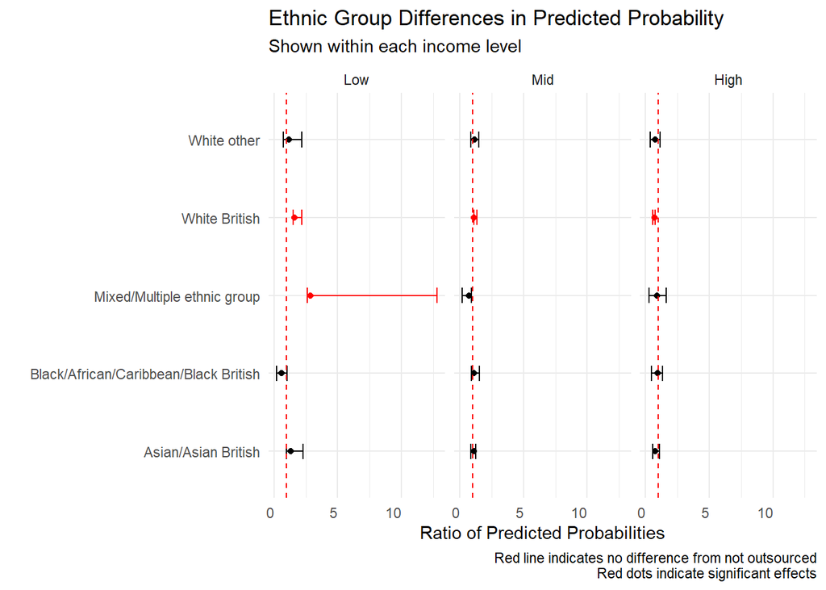

###### 3.4.3.6.2.2 Post-hoc: Ethnicity within outsourcing

Comparing ethnicities within outsourcing status,

- Among Outsourced workers, people of Mixed/Multiple ethnic group ethnicity are 2.0314837 times as likely to be in the Low group compared to White British people.
- Among Not outsourced workers, people of Asian/Asian British ethnicity are 0.9420765 times as likely to be in the High group compared to White British people.

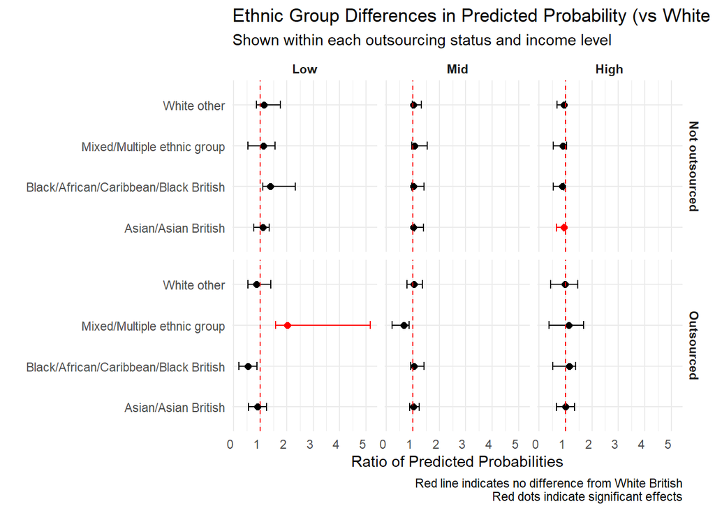

##### 3.4.3.6.3 Ethnicity 21

A model including the ethnicity:outsourcing interaction term significantly improved model fit compared to a model without the interaction term, *X^2*(38) = 2276.5041389, *p* < .001. The table below shows the model coefficients.

| income_group | estimate | std.error | statistic | p.value | conf.low | conf.high | sig |
| --- | --- | --- | --- | --- | --- | --- | --- |
| **Mid** |  |  |  |  |  |  |  |
| (Intercept) | 7.693 | 0.173 | 11.796 | 0.000 | 5.481 | 10.797 | *** |
| outsourcing_statusOutsourced | 0.700 | 0.102 | -3.479 | 0.001 | 0.573 | 0.856 | *** |
| Ethnicity_collapsed_disaggregatedIrish | 0.614 | 0.300 | -1.628 | 0.103 | 0.341 | 1.105 |  |
| Ethnicity_collapsed_disaggregatedGypsy or Irish Traveller | 3.387 | 1.073 | 1.137 | 0.256 | 0.413 | 27.760 |  |
| Ethnicity_collapsed_disaggregatedRoma | 9012209.876 | 0.308 | 51.946 | 0.000 | 4925142.568 | 16490878.330 | *** |
| Ethnicity_collapsed_disaggregatedAny other White background | 0.917 | 0.231 | -0.372 | 0.710 | 0.583 | 1.444 |  |
| Ethnicity_collapsed_disaggregatedWhite and Black Caribbean | 0.912 | 0.377 | -0.245 | 0.806 | 0.435 | 1.909 |  |
| Ethnicity_collapsed_disaggregatedWhite and Black African | 1.406 | 0.585 | 0.583 | 0.560 | 0.447 | 4.424 |  |
| Ethnicity_collapsed_disaggregatedWhite and Asian | 0.921 | 0.381 | -0.215 | 0.830 | 0.436 | 1.945 |  |
| Ethnicity_collapsed_disaggregatedAny other Mixed / Multiple ethnic background | 0.809 | 0.385 | -0.549 | 0.583 | 0.380 | 1.722 |  |
| Ethnicity_collapsed_disaggregatedIndian | 1.118 | 0.269 | 0.415 | 0.678 | 0.660 | 1.892 |  |
| Ethnicity_collapsed_disaggregatedPakistani | 0.805 | 0.314 | -0.690 | 0.490 | 0.436 | 1.489 |  |
| Ethnicity_collapsed_disaggregatedBangladeshi | 0.671 | 0.449 | -0.889 | 0.374 | 0.278 | 1.618 |  |
| Ethnicity_collapsed_disaggregatedChinese | 1.585 | 0.408 | 1.128 | 0.259 | 0.712 | 3.530 |  |
| Ethnicity_collapsed_disaggregatedAny other Asian background | 0.614 | 0.405 | -1.205 | 0.228 | 0.278 | 1.358 |  |
| Ethnicity_collapsed_disaggregatedAfrican | 0.771 | 0.243 | -1.070 | 0.285 | 0.479 | 1.241 |  |
| Ethnicity_collapsed_disaggregatedCaribbean | 0.931 | 0.404 | -0.177 | 0.860 | 0.422 | 2.056 |  |
| Ethnicity_collapsed_disaggregatedAny other Black, Black British, or Caribbean background | 0.403 | 0.479 | -1.897 | 0.058 | 0.158 | 1.031 |  |
| Ethnicity_collapsed_disaggregatedArab | 0.554 | 0.832 | -0.710 | 0.478 | 0.109 | 2.829 |  |
| Ethnicity_collapsed_disaggregatedAny other ethnic group | 3655733.353 | 0.274 | 55.213 | 0.000 | 2137957.004 | 6251008.006 | *** |
| Ethnicity_collapsed_disaggregatedDon’t think of myself as any of these | 1.575 | 1.095 | 0.415 | 0.678 | 0.184 | 13.472 |  |
| Age | 0.992 | 0.003 | -2.867 | 0.004 | 0.987 | 0.998 | ** |
| GenderFemale | 0.359 | 0.071 | -14.373 | 0.000 | 0.312 | 0.413 | *** |
| GenderOther | 0.247 | 0.668 | -2.093 | 0.036 | 0.067 | 0.915 | * |
| GenderPrefer not to say | 0.497 | 0.847 | -0.825 | 0.410 | 0.095 | 2.616 |  |
| Has_DegreeNo | 0.518 | 0.067 | -9.822 | 0.000 | 0.454 | 0.590 | *** |
| Has_DegreeDon't know | 0.313 | 0.306 | -3.800 | 0.000 | 0.172 | 0.569 | *** |
| RegionEast Midlands | 0.911 | 0.153 | -0.609 | 0.543 | 0.675 | 1.230 |  |
| RegionEast of England | 0.917 | 0.158 | -0.544 | 0.586 | 0.673 | 1.251 |  |

[output cut: 104 more lines]

###### 3.4.3.6.3.1 Post-hoc: Outsourcing within ethnicity

- White and Black Caribbean workers are 0.0000006 times as likely to be in the High group if they are outsourced compared to not-outsourced
- English / Welsh / Scottish / Northern Irish / British workers are 1.1181332 times as likely to be in the Mid group if they are outsourced compared to not-outsourced
- English / Welsh / Scottish / Northern Irish / British workers are 1.5967978 times as likely to be in the Low group if they are outsourced compared to not-outsourced
- English / Welsh / Scottish / Northern Irish / British workers are 0.7118677 times as likely to be in the High group if they are outsourced compared to not-outsourced

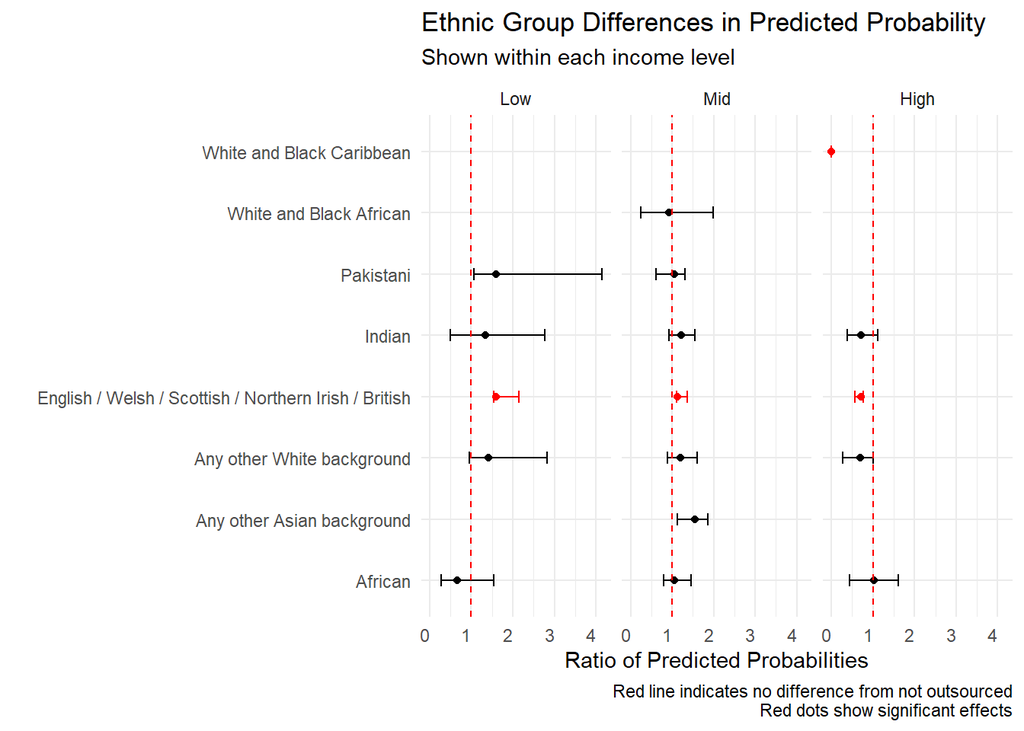

###### 3.4.3.6.3.2 Post-hoc: Ethnicity within outsourcing

Comparing ethnicities within outsourcing status,

- Among Not outsourced workers, people of Irish ethnicity are 1.7728328 times as likely to be in the Low group compared to English / Welsh / Scottish / Northern Irish / British people.

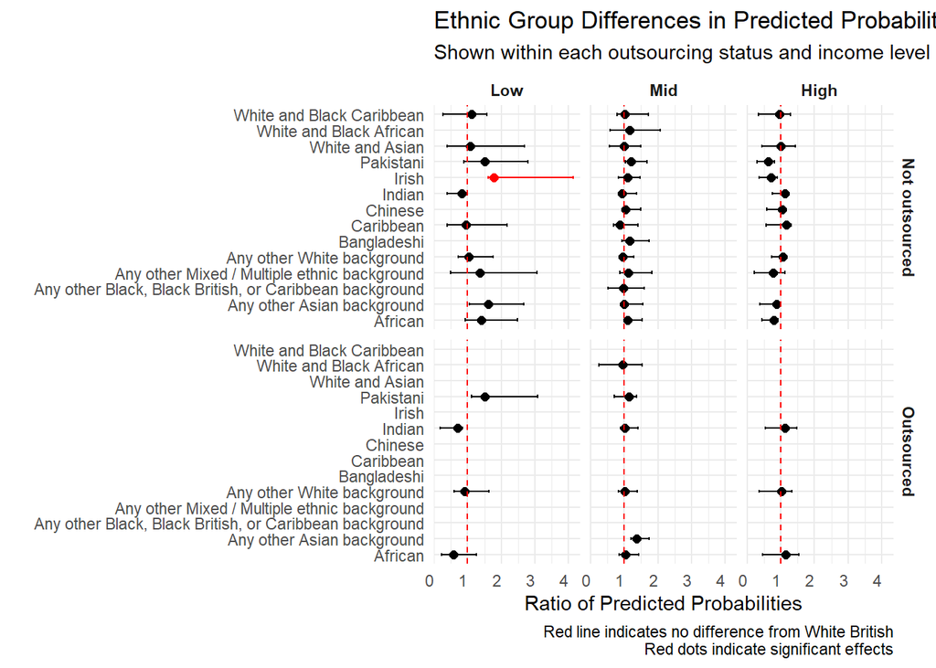

# 4 Analysis - Study 2

Due to the extensive number of variables examined, these cross-tabulations are not reproduced in this document. However, researchers can easily recreate all analyses by running the “Crosstabulations.qmd” script available in the GitHub repository associated with this project (see @reproducibility). The repository contains all necessary data files and code to replicate our findings.

# 5 Limitations and Future Research?

# 6 Reproducibility

All analyses presented in this report can be fully reproduced using the code and data provided in the [Just Knowlegde GitHub repository.](https://github.com/JustKnowledge-UK/jrf_nat_rep/tree/main)

# 7 Appendices

## 7.1 Study 1 - Age

The table below shows weighted descriptive statistics of the sample, and the figure below shows the frequency of respondents at each single year of age.

| Mean | Median | Min | Max | Standard dev. |
| --- | --- | --- | --- | --- |
| 42.1 | 42 | 16 | 80 | 13.17 |

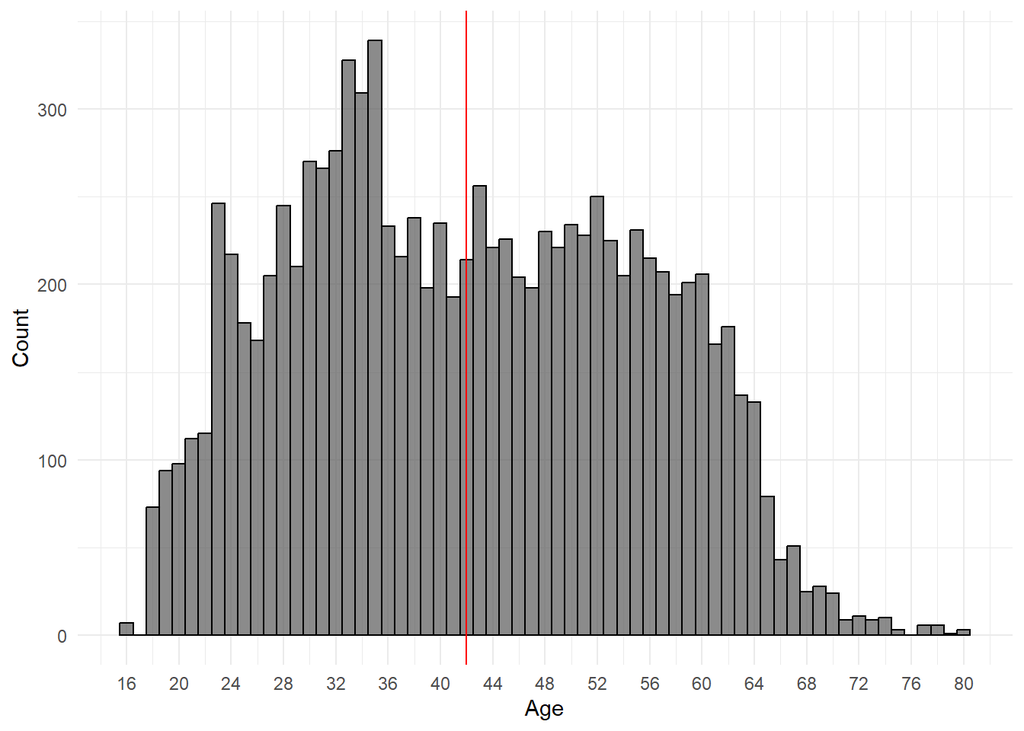

## 7.2 Study 1 - Gender

The table below shows the weighted gender breakdown of the sample

| Gender | Weighted frequency | Weighted percentage |
| --- | --- | --- |
| Male | 4957.18 | 48.82 |
| Female | 5117.61 | 50.39 |
| Other | 15.37 | 0.15 |
| Prefer not to say | 64.84 | 0.64 |

## 7.3 Study 1 - Ethnicity

The table below shows the weighted ethnicity breakdown using the full range of Census 2021 categories. Note that ‘NA’ indicates non-responses.

| Ethnicity | Weighted frequency | Weighted percentage |
| --- | --- | --- |
| English / Welsh / Scottish / Northern Irish / British | 7732.24 | 76.14 |
| Irish | 113.61 | 1.12 |
| Gypsy or Irish Traveller | 10.79 | 0.11 |
| Roma | 7.49 | 0.07 |
| Any other White background | 479.38 | 4.72 |
| White and Black Caribbean | 58.75 | 0.58 |
| White and Black African | 35.04 | 0.35 |
| White and Asian | 41.52 | 0.41 |
| Any other Mixed / Multiple ethnic background | 49.49 | 0.49 |
| Indian | 311.73 | 3.07 |
| Pakistani | 149.94 | 1.48 |
| Bangladeshi | 76.50 | 0.75 |
| Chinese | 145.53 | 1.43 |
| Any other Asian background | 163.15 | 1.61 |
| African | 227.05 | 2.24 |
| Caribbean | 71.67 | 0.71 |
| Any other Black, Black British, or Caribbean background | 37.39 | 0.37 |
| Arab | 32.50 | 0.32 |
| Any other ethnic group | 30.46 | 0.30 |
| Don’t think of myself as any of these | 8.81 | 0.09 |
| Prefer not to say | 30.45 | 0.30 |
| NA | 341.51 | 3.36 |

We also make use of an aggregated ethnicity variable that groups ethnicities into fewer categories. The table below shows how the Census categories map onto the aggregated categories.

| Census categories | Aggregated categories |
| --- | --- |
| English / Welsh / Scottish / Northern Irish / British | White British |
| Irish | White other |
| Gypsy or Irish Traveller | White other |
| Roma | White other |
| Any other White background | White other |
| White and Black Caribbean | Mixed/Multiple ethnic group |
| White and Black African | Mixed/Multiple ethnic group |
| White and Asian | Mixed/Multiple ethnic group |
| Any other Mixed / Multiple ethnic background | Mixed/Multiple ethnic group |
| Indian | Asian/Asian British |
| Pakistani | Asian/Asian British |
| Bangladeshi | Asian/Asian British |
| Chinese | Asian/Asian British |
| Any other Asian background | Asian/Asian British |
| African | Black/African/Caribbean/Black British |
| Caribbean | Black/African/Caribbean/Black British |
| Any other Black, Black British, or Caribbean background | Black/African/Caribbean/Black British |
| Arab | Arab/British Arab |
| Any other ethnic group | Other ethnic group |
| Don’t think of myself as any of these | Don't think of myself as any of these |
| Prefer not to say | Prefer not to say |
| NA | NA |

The table below shows the weighted ethnicity breakdown using the aggregated set of categories

| Ethnicity | Weighted frequency | Weighted percentage |
| --- | --- | --- |
| White British | 7732.24 | 76.14 |
| Arab/British Arab | 32.50 | 0.32 |
| Asian/Asian British | 846.86 | 8.34 |
| Black/African/Caribbean/Black British | 336.10 | 3.31 |
| Don't think of myself as any of these | 8.81 | 0.09 |
| Mixed/Multiple ethnic group | 184.80 | 1.82 |
| Other ethnic group | 30.46 | 0.30 |
| Prefer not to say | 30.45 | 0.30 |
| White other | 611.27 | 6.02 |
| NA | 341.51 | 3.36 |